# 驯鹿非鹿

2021-07-01

机器学习笔记

# PyTorch笔记

torch的tensor默认为FloatTensor类型，可以使用`torch.set_default_tensor_type(torch.DoubleTensor)`设置默认类型为DoubleTensor，pytorch和numpy的张量在内存中都是默认按行优先顺序排列。

## 基础

### 生成张量

```
1
2
3
4
5
6
7
8
9
10
11
12
13
14
```

```
x = torch.empty(5, 3) == torch.Tensor(5, 3) # 构造一个未初始化的5✖3的矩阵，里面都是任意的随机数
y = torch.rand(5, 3)   # 构造一个随机初始化的5✖3的矩阵，里面是从区间(0, 1)的均匀分布中抽取出的一组随机数
z = torch.randn(5, 3)   # 构造一个随机初始化的5✖3的矩阵，里面是从标准正态分布中抽取出的一组随机数
a = torch.zeros(5, 3, dtype=torch.int)  # 0填充，类型为整数，还可以是别的     torch.ones(5, 3)  1填充  torch.eye(3) 3×3的单位矩阵
b = torch.tensor([1, 2, 3, 4])  # 用数据直接构建向量
c = torch.randn_like(b, dtype=torch.float)  # 构造形状与b相同的随机数组,torch.ones_like,torch.zeros_like,形状相同的全1.全0

torch.randint(1, 10, [5, 3])  # 构造一个5✖3的矩阵，里面是从[1, 10)中抽取出的一组随机整数
torch.normal(mean, std)   # mean和std都是tensor，随机从mean为均值，std为方差的正太分布取值。输出形状为mean的形状。每一项一一对应，相互独立
torch.full([5, 3], 6)   # 生成一个5✖3的矩阵，并将元素全部填充为6
torch.arange(0, 10)     # tensor([0, 1, 2, 3, 4, 5, 6, 7, 8, 9])
torch.arange(0, 10, 2)  # tensor([0, 2, 4, 6, 8])
torch.linspace(0, 10, steps=4)  # tensor([ 0.0000,  3.3333,  6.6667, 10.0000])
torch.logspace(0, 1, steps=10)  # 对数函数中，y轴上在[0, 1]均匀取10个数，返回其对应的x轴上的值
```

### 常用函数及操作

```
1
2
3
4
5
6
7
8
9
10
11
12
13
14
15
16
17
18
19
20
21
22
23
24
25
26
27
28
29
30
31
32
33
34
35
36
37
38
39
40
41
```

[output not shown]

### 高级函数

- **torch.where(condition, a, b)** 根据条件选择赋值

```
1
2
3
4
5
6
7
```

```
condition = torch.rand(2, 2)   # tensor([[0.2886, 0.7170],
							#		  [0.4666, 0.5724]])
a = torch.zeros(2, 2)
b = torch.ones(2, 2)
c = torch.where(condition > 0.5, a, b)  # tensor([[1., 0.],
        					   	   	  #	        [1., 0.]])
# 相应位置，若condition在此处的值大于0.5则c在此处的值被赋予a的值，否则赋予b的值
```

- **torch.gather(input, dim, index)** 在dim维度上按index的索引搜索input的值并返回

### 维度变换

- x = x.view(3, 5)或x.reshape(3, 5) # 重塑形状，如同numpy中的reshape函数。可以将其中一个参数写为-1，解释器会自动推导。view和reshape本质不会改变数据在内存中的排列规则，只是改变了访问的规则
- unsqueeze(index) # 展开，即在index（从0开始）的位置插入一个维度，index可以为负数表示从后往前数（在之后插）
- squeeze(index) # 挤压，即在index（从0开始）的位置删除一个维度，index可以为负数表示从后往前数，当不传参时，会将所有大小为1的维度全部删除，当index位置的维度大小不为1时，不挤压，原样返回
- 上方的a.unsqueeze(index)和a.squeeze(index)都不会改变a的形状，只是返回一个改变后的形状
- expand # 维度扩张，若b之前形状为(1, 32, 1, 1) 则执行b.expand(4, 32, 14, 14)后形状变为(4, 32, 14, 14).执行b.expand(-1, 32, 14, -1)后形状变为(1, 32, 14, 1)，即传入-1的位置不做改变。repeat和expand的功能一样，但是repeat会立即在内存中拷贝所有数据，浪费内存，故不推荐使用，expand为懒复制
- a.expand_as(b) # 将a扩展为b的形状
- t() # b.t() 转置，只适用于二维
- transpose # 交换两个维度的顺序，若b之前形状为(4, 32, 14, 14) 则执行b.transpose(1, 3)后形状变为(4, 14, 14, 32)
- permute # 交换所有维度的顺序，若b之前形状为(4, 32, 14, 14) 则执行b.permute(2, 3, 1, 0)后形状变为(14, 14, 32, 4)
- transpose或permute与view一起使用时应注意的点：transpose或permute同view一样不会改变数据在内存中的排列规则，只是改变了访问的规则。但执行transpose或permute后数据访问顺序发生改变，与内存的存储顺序不一致，此时再执行view方法会发生混乱，因此需要在view方法之前执行contiguous()。contiguous()意思是连续化，即将访问顺序连续但内存位置不连续的数据，拷贝使其内存位置也连续。contiguous()方法首先拷贝了一份原始张量在内存中的地址，然后将地址按照执行transpose或permute之后的形状进行排列。之后view对新的地址改变访问规则。

### Broadcasting(自动扩展)

- Broadcasting是unsqueeze和expand的组合，由pytorch自动完成，无需手动扩展。
- 以（4， 32， 8）为例，左边的4为大维度，右边的8为小维度。Broadcasting是从小维度向大维度扩展的，即每次都是unsqueeze(0)。
- 若A和B的维度不同，则执行A + B需满足Broadcasting的条件：B中已经定义了的小维度的size要么为1要么与A的小维度size相等。若A的size为（4， 32， 8），则B的可能形状为(1), (8), (1, 1), (1, 8), (32, 1), (32, 8), (1, 1, 1), (1, 1, 8)等，其他的形状都不满足Broadcasting的条件。
- Broadcasting不是函数，不需要手动调用，在执行形状不同的tensor相加时会自动实现，例如想要在5×3的a上全部加5，则只需a+5即可

### 拼接与拆分

- torch.cat([a, b], dim=0) # 在0维上对a和b拼接，即若a的形状为(4, 2, 6),b的形状为(3, 2, 6),则拼接后形状为(7, 2, 6), 即要保持其他维度的size相等
- torch.stack([a, b], dim=0) # 在0维前插一个size为2的维度，即若a和b的形状都为(32, 8),则拼接后形状为(2, 32, 8)。stack要求a和b的形状完全一样，其中新形状的(0, 32, 8) == a; (1, 32, 8) == b。
- split() 拆分为指定份额

  ```
  1
  2
  3
  4
  5
  6
  7
  ```

  ```
  a = torch.randn(3, 32, 8)
  a1, a2 = a.split([2, 1], dim=0)   # 在0维上拆分，将3拆分为2份和1份
  a1.shape, a2.shape
  # out: (torch.Size([2, 32, 8]), torch.Size([1, 32, 8]))
  a1, a2, a3= a.split(1, dim=0)     # 在0维上拆分，1表示每份的份额为1
  a1.shape, a2.shape, a3.shape
  # out: (torch.Size([1, 32, 8]), torch.Size([1, 32, 8]), torch.Size([1, 32, 8]))
  ```

- chunk() 拆分为指定份数

  ```
  1
  2
  3
  ```

### 使用.to()方法可以将张量移动到GPU上计算：

```
1
2
3
4
5
6
```

```
if torch.cuda.is_available():
    device = torch.device("cuda")    # 指定设备为英伟达GPU
    y = torch.ones_like(x, device=device)         # 还可以f = torch.rand(4, 3, device=torch.device("cuda"))
    x = x.to(device)
    z = x + y
    print(z.to("cpu", torch.int))   # 还可以再转回cpu中.    z.to("cpu") == z.cpu()
```

### 动量

```
1
2
3
4
5
6
7
8
9
```

```
package torch.optim
class SGD(Optimizer):
    def __init__(self, params, lr=required, momentum=0, dampening=0,
                 weight_decay=0, nesterov=False)
# 上方构造函数的参数中：
	# params：模型的参数
    # momentum：动量，即上一次梯度的权重
    # weight_decay：L2正则化的权重
# Adam方法已经自动处理了动量相关
```

### 学习率衰减

learning_rate刚开始较大，加快收敛速率。之后逐渐减小，避免震荡。

```
1
2
3
4
5
6
7
8
9
10
11
12
13
14
15
16
17
18
19
20
21
22
23
24
25
```

```
# 第一种方法：监视loss，若发现loss多次不变，则减小learning_rate
optimizer = torch.optim.SGD(model.parameters(), lr=learning_rate)
# 实例化
scheduler = torch.optim.lr_scheduler.ReduceLROnPlateau(optimizer=optimizer, mode='min')

for t in range(500):
    '''forward pass'''
    y_pred = model(x)

    '''compute loss'''
    loss = loss_fn(y_pred, y)
    scheduler.step(loss)      # 监视loss，若发现loss多次不变，则减小learning_rate
-------------------------------------------------------------------------------------------
# 第二种方法：指定一定的epoch次数后减小learning_rate
optimizer = torch.optim.SGD(model.parameters(), lr=learning_rate)
# 指定每100次epoch，learning_rate = learning_rate * 0.5
scheduler = torch.optim.lr_scheduler.StepLR(optimizer=optimizer, step_size=100, gamma=0.5)

for t in range(500):
    scheduler.step()
    '''forward pass'''
    y_pred = model(x)

    '''compute loss'''
    loss = loss_fn(y_pred, y)
```

## 卷积神经网络

### 卷积操作 torch.nn.Conv2d

```
1
2
3
4
```

[output not shown]

示例

```
1
2
3
4
5
6
7
```

```
layer = torch.nn.Conv2d(1, 3, kernel_size = 3, stride=1, padding=0)
x = torch.rand(1, 1, 28, 28)   # 模拟图片
out = layer.forward(x)    # 不推荐直接使用 forward 函数
out.shape          # torch.Size([1, 3, 26, 26])
-------------------------------------------------------------------
out = layer(x)     # 推荐用这个。调用 __call__ ，封装了 hooks 和 forward 。作用与 forward 相同。
out.shape          # torch.Size([1, 3, 26, 26])
```

torch.nn.functional.conv2d 函数也可以实现卷积操作，但是不推荐。

### 池化操作 torch.nn.MaxPool2d

池化 就是 **降采样**，将原本图像缩小。分为 最大池化 和 平均池化

```
1
2
3
4
```

```
torch.nn.MaxPool2d(kernel_size, stride=None, padding=0, dilation=1, return_indices=False,
				 ceil_mode=False)
# kernel_size：核窗口大小
# stride： 步长
```

示例

```
1
2
3
```

```
pooling = torch.nn.MaxPool2d(2, stride=2)   # 最大池化
res = pooling(out)
res.shape        # torch.Size([1, 3, 13, 13])
```

torch.nn.functional.avg_pool2d 函数也可以实现池化操作，但是不推荐。

**上采样**–将原本图像放大 torch.nn.functional.interpolate

```
1
2
3
4
5
```

```
torch.nn.functional.interpolate(input, size=None, scale_factor=None, mode='nearest',
                                align_corners=None, recompute_scale_factor=None)
# input (Tensor) – the input tensor   需要放大的图像
# scale_factor ： 放大倍数
# mode ： 放大的方法。nearest 表示用最近的像素点来填充放大后周围的像素点
```

**ReLU**

```
1
2
```

```
torch.nn.ReLU(inplace=False)
# inplace： 即 in-place 运算符，将运算结果保存在自身。默认为False。一般设为True，减少内存消耗
```

### 标准化 Batch Norm

假设使用 sigmoid 函数作为激活函数，则 当数据量偏大或偏小时会出现梯度消失。故应将数据标准化为标准分布，这样会使数据有好的收敛效果且模型更稳定。（训练和测试要切换）

```
1
2
3
```

```
torch.nn.BatchNorm1d(num_features, eps=1e-05, momentum=0.1, affine=True,
                     track_running_stats=True)
# num_features：图像的通道数
```

示例

```
1
2
3
4
5
6
7
8
9
```

```
input = torch.rand(100, 16, 784)     # 28 * 28 == 784
layer = torch.nn.BatchNorm1d(16)     # 也可以不压缩，用二维的方法
out = layer(input)
layer.running_mean    # 均值
# tensor([0.0499, 0.0500, 0.0500, 0.0500, 0.0501, 0.0499, 0.0500, 0.0501, 0.0501,
#         0.0500, 0.0501, 0.0502, 0.0498, 0.0501, 0.0500, 0.0500])
layer.running_var     # 方差
# tensor([0.9083, 0.9083, 0.9083, 0.9084, 0.9083, 0.9084, 0.9083, 0.9083, 0.9083,
#         0.9083, 0.9084, 0.9083, 0.9083, 0.9083, 0.9084, 0.9083])
```

标准化过程：

- 求一个通道内的所有像素的 均值 E[x] 和 方差 Var[x]
- 用公式标准化
- 之后迭代更新 γ 和 β

### 残差神经网络

普通神经网络在层数达到二十层时，会达到一个瓶颈，即层数继续叠加，效果反而变差。

残差神经网络在浅层与深层之间增加了一个短路直连，当深层的效果更好时，就选择该值，若更差就退化为浅层神经网络。使得深层网络最差也不会差于浅层神经网络。

示例：

```
1
2
3
4
5
6
7
8
9
10
11
12
13
14
15
16
17
18
19
20
21
22
```

```
class ResBlk(nn.Module):
    def __init__(self, in_ch, out_ch):
        super(ResBlk, self).__init__()
        self.conv1 = nn.Conv2d(in_ch, out_ch, kernel_size=3, stride=1, padding=1)
        self.bn1 = nn.BatchNorm2d(out_ch)
        self.relu = nn.ReLU()
        self.conv2 = nn.Conv2d(out_ch, out_ch, kernel_size=3, stride=1, padding=1)
        self.bn2 = nn.BatchNorm2d(out_ch)

        self.extra = nn.Sequential()  # 若输入通道等于输出通道，则直连

        if out_ch != in_ch:
            self.extra = nn.Sequential(  # 若输入通道不等于输出通道，则用1 × 1的核函数使其相等
                nn.Conv2d(in_ch, out_ch, kernel_size=1, stride=1),
                nn.BatchNorm2d(out_ch)
            )

    def forward(self, x):
        out = self.relu(self.bn1(self.conv1(x)))
        out = self.bn2(self.conv2(out))   # 完成一个单元你的输出
        out = self.extra(x) + out         # 直连输出与单元输出相加
        return out
```

**铺平 torch.nn.Flatten**

卷积神经网络的后边会有一个全连接层，前面的卷积池化操作是二维的，而全连接层是一维的，故中间需要将二维铺平为一维。

```
1
2
3
4
5
6
```

```
class Flatten(nn.Module):
    def __init__(self):
        super(Flatten, self).__init__()

    def forward(self, input):
        return input.view(input.size(0), -1)
```

**线性容器 torch.nn.Sequential**

按添加的顺序依次执行

```
1
2
3
4
5
6
7
8
9
10
11
12
```

```
class TestNet(nn.Module):
    def __init__(self):
        super(TestNet, self).__init__()
        self.net = nn.Sequential(
            nn.Conv2d(1, 16, stride=1, padding=1),
            nn.MaxPool2d(2, 2),
            Flatten(),      # 即上方定义的Flatten
            nn.Linear(1 * 14 * 14, 10)
        )

    def forward(self, x):
        return self.net(x)   # 按线性容器中的顺序执行
```

**参数包装 torch.nn.parameter.Parameter**

参数通过该类包装后会自动添加到模型的参数列表中，即`model.parameters()`。自动求导迭代优化。

```
1
2
3
4
5
6
7
8
9
```

```
class MyLinear(nn.Module):
    def __init__(self, in, out):
        super(MyLinear, self).__init__()
        self.w = nn.parameter.Parameter(torch.randn(out, in))
        self.b = nn.parameter.Parameter(torch.randn(out))

    def forward(self, x):
        x = x @ self.w.t() + self.b
        return x
```

**数据增强**

通过翻转、旋转、裁剪、缩放等方法，把原来少量的数据集扩大。

## 循环神经网络

**GloVe 词向量**

```
1
2
3
4
5
```

```
from torchnlp.word_to_vector import GloVe

vectors = GloVe()   # 全局词向量。词与其向量组成的dict

vectors['hello']    # 输出该词的向量
```

### torch.nn.RNN

[torch.nn.RNN参数的详解](https://blog.csdn.net/SHU15121856/article/details/104387209)

[数据如何传入RNN网络](https://zhuanlan.zhihu.com/p/32103001)

```
1
2
3
4
5
6
7
8
9
10
11
12
13
```

```
import torch
from torch import nn

# 表示feature_len=100, hidden_len=20, 层数=1
rnn = nn.RNN(100, 20, 1)
# 输入3个样本序列(batch=3), 序列长为10(seq_len=10), 每个特征100维度(feature_len=100)
# 即有3句话，每句话的单词数为10，每个单词用100维向量表示
x = torch.randn(10, 3, 100)
# 传入RNN处理, 另外传入h_0, shape是<层数, batch, hidden_len=20>
out, h = rnn(x, torch.zeros(1, 3, 20))
# 输出返回的out和最终的隐藏记忆单元的shape
print(out.shape)  # torch.Size([10, 3, 20])
print(h.shape)  # torch.Size([1, 3, 20])
```

对于一个RNN单元的输出 h~t ，乘以权重矩阵W变为out，乘以权重矩阵V变为下一个时间节点的输入。但是一般好像不存在W和V，因此两个输入是同一个东西。

### LSTM

LSTM在原理上通过三道门控制当前单词与过去单词的权重，在pytorch实现上面仅是增加了一个参数 c 来表示过去的记忆。

2021-07-01

机器学习笔记

# Numpy笔记

Numpy笔记

2021-07-01

机器学习笔记

# Pandas笔记

Pandas笔记

2021-07-01

机器学习笔记

# Matplotlib笔记

Matplotlib笔记

2021-07-01

```python
import matplotlib.pyplot as plt
import numpy as np
```

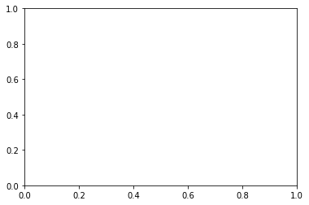

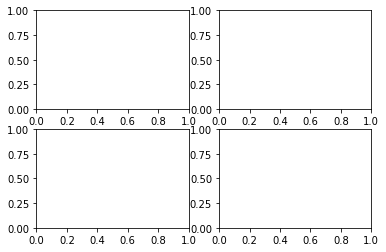

```python
fig = plt.figure()  # an empty figure with no Axes
fig, ax = plt.subplots()  # a figure with a single Axes
fig, axs = plt.subplots(2, 2)  # a figure with a 2x2 grid of Axes
```

```python
ax.plot([1, 2, 3, 4], [1, 4, 2, 3])  # Plot some data on the axes.
```

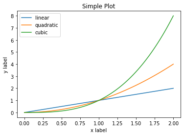

```python
x = np.linspace(0, 2, 100)

# Note that even in the OO-style, we use `.pyplot.figure` to create the figure.
fig, ax = plt.subplots()  # Create a figure and an axes.
ax.plot(x, x, label='linear')  # Plot some data on the axes.
ax.plot(x, x**2, label='quadratic')  # Plot more data on the axes...
ax.plot(x, x**3, label='cubic')  # ... and some more.
ax.set_xlabel('x label')  # Add an x-label to the axes.
ax.set_ylabel('y label')  # Add a y-label to the axes.
ax.set_title("Simple Plot")  # Add a title to the axes.
ax.legend()  # Add a legend.
```

```python
plt.ion()    # 开启交互模式，即输入命令后会直接将图形展示出来
plt.ioff()   # 关闭交互模式，即输入命令后不会直接将图形展示出来，需要输入plt.show()才会展示图形
```

```python
# 以上介绍的是面向对象的使用方法，但是更常用的是 pyplot API 方法，如下：
```

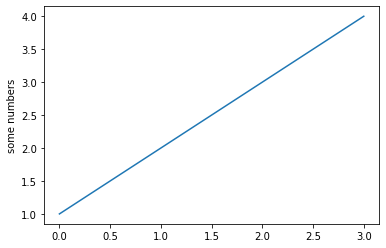

```python
import matplotlib.pyplot as plt
plt.plot([1, 2, 3, 4])     # x轴默认为 lan(y)，从0开始
plt.ylabel('some numbers')
plt.show()
```

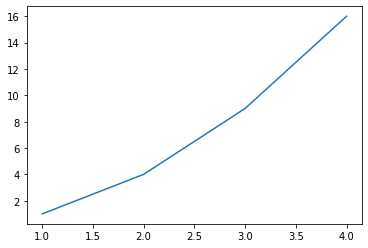

```python
plt.plot([1, 2, 3, 4], [1, 4, 9, 16])     # 用 plt.plot 即可直接创建图形，无需先创建画布   fig, ax = plt.subplots()
```

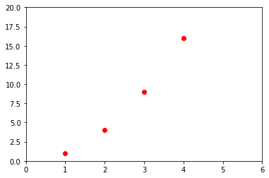

```python
plt.plot([1, 2, 3, 4], [1, 4, 9, 16], 'ro')    # 其余参数可以指定线形和颜色、默认为蓝实线。此处指定为红色圆圈
plt.axis([0, 6, 0, 20])                        # [xmin, xmax, ymin, ymax]  指定 x 轴和 y 轴的范围
plt.show()
```

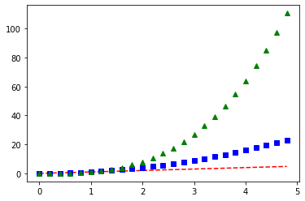

```python
# evenly sampled time at 200ms intervals
t = np.arange(0., 5., 0.2)

# red dashes, blue squares and green triangles
plt.plot(t, t, 'r--', t, t**2, 'bs', t, t**3, 'g^')
plt.show()
```

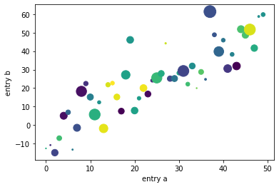

```python
data = {'a': np.arange(50),
        'c': np.random.randint(0, 50, 50),
        'd': np.random.randn(50)}
data['b'] = data['a'] + 10 * np.random.randn(50)
data['d'] = np.abs(data['d']) * 100

# matplotlib.pyplot.scatter(x, y, s=None, c=None, marker=None, data=None, ....)
# 该函数用于绘制散点图，x 和 y 为坐标（长度需相等）；c控制颜色，一般传入与xy等长的数组为每个点指定不同颜色，易于区分。
# s控制点的大小，本例s传入一个数组，使每个点的大小不同，更美观。marker控制点的形状。
plt.scatter('a', 'b', c='c', s='d',marker='o', data=data)
plt.xlabel('entry a')
plt.ylabel('entry b')
plt.show()
```

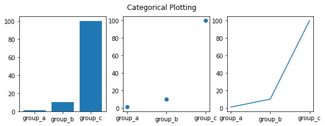

```python
names = ['group_a', 'group_b', 'group_c']
values = [1, 10, 100]

plt.figure(figsize=(9, 3))    # 新建画布，宽 9 ，高 3

# 拆分子画布，plt.subplot(nrows, ncols, index) index指向当前画布（可以是元组，包含多个子画布） plt.subplot(131) 等同于plt.subplot(1，3，1)
plt.subplot(131)
plt.bar(names, values)        # 条形图
plt.subplot(132)
plt.scatter(names, values)    # 散点图
plt.subplot(133)
plt.plot(names, values)       # 普通折线图
plt.suptitle('Categorical Plotting')
plt.show()
```

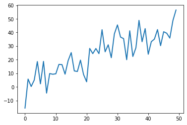

```python
x = np.arange(50)
y = x + 10 * np.random.randn(50)
plt.plot(x, y, linewidth=2.0)            # 通过关键字的方法 设置线宽
```

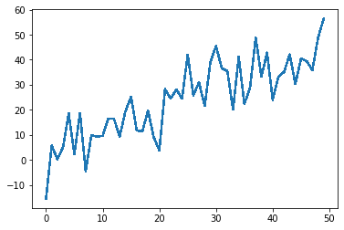

```python
# 关于python的返回值解包：
#     普通函数若返回一个值，则不会包装就是返回值本身；若返回多个值，当用一个变量接受时会封装为一个元组
#                                                                   当用相等个数变量接收时就是对应的值本身，这就是解包装
#     如下方函数 plt.plot 返回的是一个手动封装好的列表，则
#           line = plt.plot(x, y, '-') ，line为一个列表（列表中只有一个元素）
#           line, = plt.plot(x, y, '-')，line就是列表中的第一个元素。line后的逗号就解包装的提示
#      类似 line1，line2 = plt.plot(x1, y1, x2, y2) 也是解包装
line, = plt.plot(x, y, '-')  # plt.plot 返回由图形对象组成的列表
line.set_antialiased(False) # 通过 获得图形对象，并对其用set方法关闭抗锯齿
```

[output not shown]

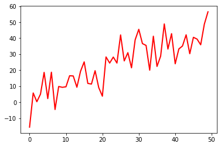

```python
# 用setp方法也能设置图形的属性
lines = plt.plot(x, y)
# use keyword args
plt.setp(lines, color='r', linewidth=2.0)
# or MATLAB style string value pairs
plt.setp(lines, 'color', 'r', 'linewidth', 2.0)
```

[output not shown]

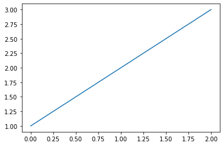

```python
lines = plt.plot([1, 2, 3])
plt.setp(lines)      # 获取 lines 的所有属性
```

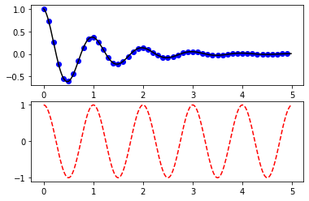

```python
def f(t):
    return np.exp(-t) * np.cos(2*np.pi*t)

t1 = np.arange(0.0, 5.0, 0.1)
t2 = np.arange(0.0, 5.0, 0.02)

plt.figure()
plt.subplot(211)
plt.plot(t1, f(t1), 'bo', t2, f(t2), 'k')   # 蓝圈， 黑线

plt.subplot(212)
plt.plot(t2, np.cos(2*np.pi*t2), 'r--')    # 红虚线
plt.show()
```

```python
# 轴不仅可以放在左下角，还可以手动放在任意位置
```

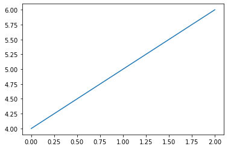

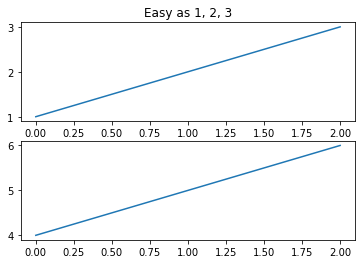

```python
# 切换 轴 和 画布
import matplotlib.pyplot as plt
plt.figure(1)                # the first figure
plt.subplot(211)             # the first subplot in the first figure
plt.plot([1, 2, 3])
plt.subplot(212)             # the second subplot in the first figure
plt.plot([4, 5, 6])


plt.figure(2)                # a second figure
plt.plot([4, 5, 6])          # creates a subplot() by default

plt.figure(1)                # figure 1 current; subplot(212) still current
plt.subplot(211)             # make subplot(211) in figure1 current
plt.title('Easy as 1, 2, 3') # subplot 211 title
```

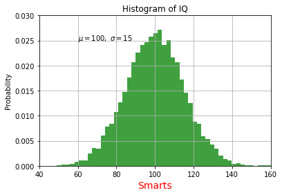

```python
import numpy as np
mu, sigma = 100, 15
x = mu + sigma * np.random.randn(10000)

# 直方图  matplot.pyplot.hist(x, bins=None, range=None, density=None,
# 参数中 bins 若为整数表示柱子的个数,density 若为True表示柱子原始值除以所有柱子总面积之和（即频数变为频率）
n, bins, patches = plt.hist(x, 50, density=True, facecolor='g', alpha=0.75)


plt.xlabel('Smarts', fontsize=14, color='red') # 可以对行/列标签设置属性
plt.ylabel('Probability')
plt.title('Histogram of IQ')
plt.text(60, .025, r'$\mu=100,\ \sigma=15$')   # 在坐标（60, 0.025）处添加值   由 $ 号包围的 LaTeX 语法
plt.axis([40, 160, 0, 0.03])
plt.grid(True)                                # 有无网格
plt.show()
```

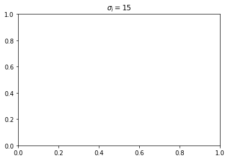

```python
# matplotlib 可以在任何输入文本的地方输入  LaTeX 表达式  ,如下：
plt.title(r'$\sigma_i=15$')
```

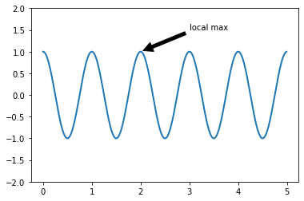

```python
# plt.annotate 注释文本，对绘图的某些特征进行注释
ax = plt.subplot()

t = np.arange(0.0, 5.0, 0.01)
s = np.cos(2*np.pi*t)
line, = plt.plot(t, s, lw=2)

plt.annotate('local max', xy=(2, 1), xytext=(3, 1.5),   # 分别为 注释的内容、注释指向的位置、注释所在的位置
             arrowprops=dict(facecolor='black', shrink=0.05),  # 箭头的参数
             )

plt.ylim(-2, 2)   # 设置当前轴的y的范围
plt.show()
```

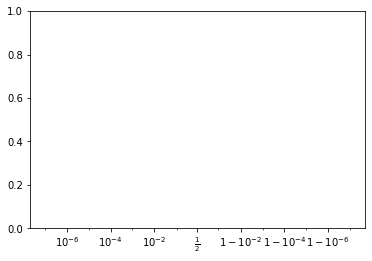

```python
# matplotlib 还支持非线性的坐标刻度
plt.xscale('logit')
```

```python
#
```

2021-07-01

```python
import torch
```

```python
import numpy as np
import pandas as pd
```

```python
s = pd.Series([1, 2, 3, np.nan, 5, 8])
```

```python
s
```

```
0    1.0
1    2.0
2    3.0
3    NaN
4    5.0
5    8.0
dtype: float64
```

```python
type(s)
```

```
pandas.core.series.Series
```

```python
dates = pd.date_range('20210619', periods=6)
```

```python
dates
```

```
DatetimeIndex(['2021-06-19', '2021-06-20', '2021-06-21', '2021-06-22',
               '2021-06-23', '2021-06-24'],
              dtype='datetime64[ns]', freq='D')
```

```python
df = pd.DataFrame(np.random.randn(6, 4), index=dates, columns=list('ABCD'))
```

```python
df
```

|  | A | B | C | D |
| --- | --- | --- | --- | --- |
| 2021-06-19 | 0.386467 | 0.946613 | 0.141736 | -0.200258 |
| 2021-06-20 | 0.271687 | -1.356886 | 0.817206 | 0.405909 |
| 2021-06-21 | 1.059778 | -1.025067 | 0.652449 | -0.078852 |
| 2021-06-22 | -1.696832 | 0.778534 | 0.983199 | 1.084013 |
| 2021-06-23 | -1.337686 | -1.097497 | -1.486640 | 1.038132 |
| 2021-06-24 | -0.221562 | -1.272950 | -0.531797 | -0.275663 |

```python
df2 = pd.DataFrame({'A': 1.,
                    'B': pd.Timestamp('20210619'),
                    'C': pd.Series(1, index=list(range(4)), dtype='float32'),
                    'D': np.array([3] * 4, dtype='int32'),
                    'E': pd.Categorical(["test", "train", "test", "train"]),
                    'F': 'foo'})
```

```python
df2
```

|  | A | B | C | D | E | F |
| --- | --- | --- | --- | --- | --- | --- |
| 0 | 1.0 | 2021-06-19 | 1.0 | 3 | test | foo |
| 1 | 1.0 | 2021-06-19 | 1.0 | 3 | train | foo |
| 2 | 1.0 | 2021-06-19 | 1.0 | 3 | test | foo |
| 3 | 1.0 | 2021-06-19 | 1.0 | 3 | train | foo |

```python
df2.dtypes
```

```
A           float64
B    datetime64[ns]
C           float32
D             int32
E          category
F            object
dtype: object
```

```python
df2.A
```

```
0    1.0
1    1.0
2    1.0
3    1.0
Name: A, dtype: float64
```

```python
df.head(2)
```

|  | A | B | C | D |
| --- | --- | --- | --- | --- |
| 2021-06-19 | 0.386467 | 0.946613 | 0.141736 | -0.200258 |
| 2021-06-20 | 0.271687 | -1.356886 | 0.817206 | 0.405909 |

```python
df.tail(3)
```

|  | A | B | C | D |
| --- | --- | --- | --- | --- |
| 2021-06-22 | -1.696832 | 0.778534 | 0.983199 | 1.084013 |
| 2021-06-23 | -1.337686 | -1.097497 | -1.486640 | 1.038132 |
| 2021-06-24 | -0.221562 | -1.272950 | -0.531797 | -0.275663 |

```python
df.index
```

```
DatetimeIndex(['2021-06-19', '2021-06-20', '2021-06-21', '2021-06-22',
               '2021-06-23', '2021-06-24'],
              dtype='datetime64[ns]', freq='D')
```

```python
df.columns
```

```
Index(['A', 'B', 'C', 'D'], dtype='object')
```

```python
df.to_numpy()
```

```
array([[ 0.38646654,  0.94661295,  0.14173562, -0.20025788],
       [ 0.27168667, -1.35688554,  0.81720576,  0.40590944],
       [ 1.05977787, -1.02506746,  0.65244942, -0.07885209],
       [-1.69683156,  0.77853378,  0.98319935,  1.0840126 ],
       [-1.33768634, -1.09749733, -1.48663953,  1.03813154],
       [-0.22156172, -1.27294978, -0.53179663, -0.2756628 ]])
```

```python
df2.to_numpy()
```

```
array([[1.0, Timestamp('2021-06-19 00:00:00'), 1.0, 3, 'test', 'foo'],
       [1.0, Timestamp('2021-06-19 00:00:00'), 1.0, 3, 'train', 'foo'],
       [1.0, Timestamp('2021-06-19 00:00:00'), 1.0, 3, 'test', 'foo'],
       [1.0, Timestamp('2021-06-19 00:00:00'), 1.0, 3, 'train', 'foo']],
      dtype=object)
```

```python
df.describe()
```

|  | A | B | C | D |
| --- | --- | --- | --- | --- |
| count | 6.000000 | 6.000000 | 6.000000 | 6.000000 |
| mean | -0.256358 | -0.504542 | 0.096026 | 0.328880 |
| std | 1.064868 | 1.066922 | 0.950565 | 0.614964 |
| min | -1.696832 | -1.356886 | -1.486640 | -0.275663 |
| 25% | -1.058655 | -1.229087 | -0.363414 | -0.169906 |
| 50% | 0.025062 | -1.061282 | 0.397093 | 0.163529 |
| 75% | 0.357772 | 0.327633 | 0.776017 | 0.880076 |
| max | 1.059778 | 0.946613 | 0.983199 | 1.084013 |

```python
df
```

|  | A | B | C | D |
| --- | --- | --- | --- | --- |
| 2021-06-19 | 0.386467 | 0.946613 | 0.141736 | -0.200258 |
| 2021-06-20 | 0.271687 | -1.356886 | 0.817206 | 0.405909 |
| 2021-06-21 | 1.059778 | -1.025067 | 0.652449 | -0.078852 |
| 2021-06-22 | -1.696832 | 0.778534 | 0.983199 | 1.084013 |
| 2021-06-23 | -1.337686 | -1.097497 | -1.486640 | 1.038132 |
| 2021-06-24 | -0.221562 | -1.272950 | -0.531797 | -0.275663 |

```python
df.T
```

|  | 2021-06-19 | 2021-06-20 | 2021-06-21 | 2021-06-22 | 2021-06-23 | 2021-06-24 |
| --- | --- | --- | --- | --- | --- | --- |
| A | 0.386467 | 0.271687 | 1.059778 | -1.696832 | -1.337686 | -0.221562 |
| B | 0.946613 | -1.356886 | -1.025067 | 0.778534 | -1.097497 | -1.272950 |
| C | 0.141736 | 0.817206 | 0.652449 | 0.983199 | -1.486640 | -0.531797 |
| D | -0.200258 | 0.405909 | -0.078852 | 1.084013 | 1.038132 | -0.275663 |

```python
df.sort_index(axis=0, ascending=False)
```

|  | A | B | C | D |
| --- | --- | --- | --- | --- |
| 2021-06-24 | -0.221562 | -1.272950 | -0.531797 | -0.275663 |
| 2021-06-23 | -1.337686 | -1.097497 | -1.486640 | 1.038132 |
| 2021-06-22 | -1.696832 | 0.778534 | 0.983199 | 1.084013 |
| 2021-06-21 | 1.059778 | -1.025067 | 0.652449 | -0.078852 |
| 2021-06-20 | 0.271687 | -1.356886 | 0.817206 | 0.405909 |
| 2021-06-19 | 0.386467 | 0.946613 | 0.141736 | -0.200258 |

```python
df.sort_values(by='C', ascending=False)
```

|  | A | B | C | D |
| --- | --- | --- | --- | --- |
| 2021-06-22 | -1.696832 | 0.778534 | 0.983199 | 1.084013 |
| 2021-06-20 | 0.271687 | -1.356886 | 0.817206 | 0.405909 |
| 2021-06-21 | 1.059778 | -1.025067 | 0.652449 | -0.078852 |
| 2021-06-19 | 0.386467 | 0.946613 | 0.141736 | -0.200258 |
| 2021-06-24 | -0.221562 | -1.272950 | -0.531797 | -0.275663 |
| 2021-06-23 | -1.337686 | -1.097497 | -1.486640 | 1.038132 |

```python
df['A']
```

```
2021-06-19    0.386467
2021-06-20    0.271687
2021-06-21    1.059778
2021-06-22   -1.696832
2021-06-23   -1.337686
2021-06-24   -0.221562
Freq: D, Name: A, dtype: float64
```

```python
df[:3]
```

|  | A | B | C | D |
| --- | --- | --- | --- | --- |
| 2021-06-19 | 0.386467 | 0.946613 | 0.141736 | -0.200258 |
| 2021-06-20 | 0.271687 | -1.356886 | 0.817206 | 0.405909 |
| 2021-06-21 | 1.059778 | -1.025067 | 0.652449 | -0.078852 |

```python
df.loc['20210619', :]
```

```
A    0.386467
B    0.946613
C    0.141736
D   -0.200258
Name: 2021-06-19 00:00:00, dtype: float64
```

```python
df
```

|  | A | B | C | D |
| --- | --- | --- | --- | --- |
| 2021-06-19 | 0.386467 | 0.946613 | 0.141736 | -0.200258 |
| 2021-06-20 | 0.271687 | -1.356886 | 0.817206 | 0.405909 |
| 2021-06-21 | 1.059778 | -1.025067 | 0.652449 | -0.078852 |
| 2021-06-22 | -1.696832 | 0.778534 | 0.983199 | 1.084013 |
| 2021-06-23 | -1.337686 | -1.097497 | -1.486640 | 1.038132 |
| 2021-06-24 | -0.221562 | -1.272950 | -0.531797 | -0.275663 |

```python
df.iloc[3]
```

```
A   -1.696832
B    0.778534
C    0.983199
D    1.084013
Name: 2021-06-22 00:00:00, dtype: float64
```

```python
df.iloc[[1, 2, 4], [1, 3]]
```

|  | B | D |
| --- | --- | --- |
| 2021-06-20 | -1.356886 | 0.405909 |
| 2021-06-21 | -1.025067 | -0.078852 |
| 2021-06-23 | -1.097497 | 1.038132 |

```python
df[['A','B']]
```

|  | A | B |
| --- | --- | --- |
| 2021-06-19 | 0.386467 | 0.946613 |
| 2021-06-20 | 0.271687 | -1.356886 |
| 2021-06-21 | 1.059778 | -1.025067 |
| 2021-06-22 | -1.696832 | 0.778534 |
| 2021-06-23 | -1.337686 | -1.097497 |
| 2021-06-24 | -0.221562 | -1.272950 |

```python
df[df.A > 0]
```

|  | A | B | C | D |
| --- | --- | --- | --- | --- |
| 2021-06-19 | 0.386467 | 0.946613 | 0.141736 | -0.200258 |
| 2021-06-20 | 0.271687 | -1.356886 | 0.817206 | 0.405909 |
| 2021-06-21 | 1.059778 | -1.025067 | 0.652449 | -0.078852 |

```python
df[df > 0]
```

|  | A | B | C | D |
| --- | --- | --- | --- | --- |
| 2021-06-19 | 0.386467 | 0.946613 | 0.141736 | NaN |
| 2021-06-20 | 0.271687 | NaN | 0.817206 | 0.405909 |
| 2021-06-21 | 1.059778 | NaN | 0.652449 | NaN |
| 2021-06-22 | NaN | 0.778534 | 0.983199 | 1.084013 |
| 2021-06-23 | NaN | NaN | NaN | 1.038132 |
| 2021-06-24 | NaN | NaN | NaN | NaN |

```python
df2 = df.copy()
df2['E'] = ['one', 'one', 'two', 'three', 'four', 'three']
```

```python
df2
```

|  | A | B | C | D | E |
| --- | --- | --- | --- | --- | --- |
| 2021-06-19 | 0.386467 | 0.946613 | 0.141736 | -0.200258 | one |
| 2021-06-20 | 0.271687 | -1.356886 | 0.817206 | 0.405909 | one |
| 2021-06-21 | 1.059778 | -1.025067 | 0.652449 | -0.078852 | two |
| 2021-06-22 | -1.696832 | 0.778534 | 0.983199 | 1.084013 | three |
| 2021-06-23 | -1.337686 | -1.097497 | -1.486640 | 1.038132 | four |
| 2021-06-24 | -0.221562 | -1.272950 | -0.531797 | -0.275663 | three |

```python
df2[df2['E'].isin(['two', 'four'])]
```

|  | A | B | C | D | E |
| --- | --- | --- | --- | --- | --- |
| 2021-06-21 | 1.059778 | -1.025067 | 0.652449 | -0.078852 | two |
| 2021-06-23 | -1.337686 | -1.097497 | -1.486640 | 1.038132 | four |

```python
s1 = pd.Series([1, 2, 3, 4, 5, 6], index=pd.date_range('20130102', periods=6))
```

```python
s1
```

```
2013-01-02    1
2013-01-03    2
2013-01-04    3
2013-01-05    4
2013-01-06    5
2013-01-07    6
Freq: D, dtype: int64
```

```python
df.at[dates[0], 'A'] = 0
```

```python
df
```

|  | A | B | C | D |
| --- | --- | --- | --- | --- |
| 2021-06-19 | 0.000000 | 0.946613 | 0.141736 | -0.200258 |
| 2021-06-20 | 0.271687 | -1.356886 | 0.817206 | 0.405909 |
| 2021-06-21 | 1.059778 | -1.025067 | 0.652449 | -0.078852 |
| 2021-06-22 | -1.696832 | 0.778534 | 0.983199 | 1.084013 |
| 2021-06-23 | -1.337686 | -1.097497 | -1.486640 | 1.038132 |
| 2021-06-24 | -0.221562 | -1.272950 | -0.531797 | -0.275663 |

```python
df.iat[0, 1] = 0
```

```python
df
```

|  | A | B | C | D |
| --- | --- | --- | --- | --- |
| 2021-06-19 | 0.000000 | 0.000000 | 0.141736 | -0.200258 |
| 2021-06-20 | 0.271687 | -1.356886 | 0.817206 | 0.405909 |
| 2021-06-21 | 1.059778 | -1.025067 | 0.652449 | -0.078852 |
| 2021-06-22 | -1.696832 | 0.778534 | 0.983199 | 1.084013 |
| 2021-06-23 | -1.337686 | -1.097497 | -1.486640 | 1.038132 |
| 2021-06-24 | -0.221562 | -1.272950 | -0.531797 | -0.275663 |

```python
len(df)
```

```
6
```

```python
df.size
```

```
24
```

```python
df.D = np.array([5] * len(df))
```

```python
df
```

|  | A | B | C | D |
| --- | --- | --- | --- | --- |
| 2021-06-19 | 0.000000 | 0.000000 | 0.141736 | 5 |
| 2021-06-20 | 0.271687 | -1.356886 | 0.817206 | 5 |
| 2021-06-21 | 1.059778 | -1.025067 | 0.652449 | 5 |
| 2021-06-22 | -1.696832 | 0.778534 | 0.983199 | 5 |
| 2021-06-23 | -1.337686 | -1.097497 | -1.486640 | 5 |
| 2021-06-24 | -0.221562 | -1.272950 | -0.531797 | 5 |

```python
df2 = df.copy()
```

```python
df2[df2 > 0] = -df2
```

```python
df2
```

|  | A | B | C | D |
| --- | --- | --- | --- | --- |
| 2021-06-19 | 0.000000 | 0.000000 | -0.141736 | -5 |
| 2021-06-20 | -0.271687 | -1.356886 | -0.817206 | -5 |
| 2021-06-21 | -1.059778 | -1.025067 | -0.652449 | -5 |
| 2021-06-22 | -1.696832 | -0.778534 | -0.983199 | -5 |
| 2021-06-23 | -1.337686 | -1.097497 | -1.486640 | -5 |
| 2021-06-24 | -0.221562 | -1.272950 | -0.531797 | -5 |

```python
df1 = df.reindex(index=dates[0:4], columns=list(df.columns) + ['E', 'F'])
```

```python
df1.iloc[:2, 4] = 1
```

```python
df1.iloc[1:4, 5] = np.array([1, 2, 3])
```

```python
df1
```

|  | A | B | C | D | E | F |
| --- | --- | --- | --- | --- | --- | --- |
| 2021-06-19 | 0.000000 | 0.000000 | 0.141736 | 5 | 1.0 | NaN |
| 2021-06-20 | 0.271687 | -1.356886 | 0.817206 | 5 | 1.0 | 1.0 |
| 2021-06-21 | 1.059778 | -1.025067 | 0.652449 | 5 | NaN | 2.0 |
| 2021-06-22 | -1.696832 | 0.778534 | 0.983199 | 5 | NaN | 3.0 |

```python
df1.dropna(how='any')
```

|  | A | B | C | D | E | F |
| --- | --- | --- | --- | --- | --- | --- |
| 2021-06-20 | 0.271687 | -1.356886 | 0.817206 | 5 | 1.0 | 1.0 |

```python
df1.fillna(value=5)
```

|  | A | B | C | D | E | F |
| --- | --- | --- | --- | --- | --- | --- |
| 2021-06-19 | 0.000000 | 0.000000 | 0.141736 | 5 | 1.0 | 5.0 |
| 2021-06-20 | 0.271687 | -1.356886 | 0.817206 | 5 | 1.0 | 1.0 |
| 2021-06-21 | 1.059778 | -1.025067 | 0.652449 | 5 | 5.0 | 2.0 |
| 2021-06-22 | -1.696832 | 0.778534 | 0.983199 | 5 | 5.0 | 3.0 |

```python
pd.isna(df1)
```

|  | A | B | C | D | E | F |
| --- | --- | --- | --- | --- | --- | --- |
| 2021-06-19 | False | False | False | False | False | True |
| 2021-06-20 | False | False | False | False | False | False |
| 2021-06-21 | False | False | False | False | True | False |
| 2021-06-22 | False | False | False | False | True | False |

```python
df
```

|  | A | B | C | D |
| --- | --- | --- | --- | --- |
| 2021-06-19 | 0.000000 | 0.000000 | 0.141736 | 5 |
| 2021-06-20 | 0.271687 | -1.356886 | 0.817206 | 5 |
| 2021-06-21 | 1.059778 | -1.025067 | 0.652449 | 5 |
| 2021-06-22 | -1.696832 | 0.778534 | 0.983199 | 5 |
| 2021-06-23 | -1.337686 | -1.097497 | -1.486640 | 5 |
| 2021-06-24 | -0.221562 | -1.272950 | -0.531797 | 5 |

```python
df.mean()
```

```
A   -0.320769
B   -0.662311
C    0.096026
D    5.000000
dtype: float64
```

```python
df.mean(1)
```

```
2021-06-19    1.285434
2021-06-20    1.183002
2021-06-21    1.421790
2021-06-22    1.266225
2021-06-23    0.269544
2021-06-24    0.743423
Freq: D, dtype: float64
```

```python
s = pd.Series([1, 2, 4, np.nan, 6, 8], index=dates).shift(2)
```

```python
s
```

```
2021-06-19    NaN
2021-06-20    NaN
2021-06-21    1.0
2021-06-22    2.0
2021-06-23    4.0
2021-06-24    NaN
Freq: D, dtype: float64
```

```python
df.sub(s, axis=0)
```

|  | A | B | C | D |
| --- | --- | --- | --- | --- |
| 2021-06-19 | NaN | NaN | NaN | NaN |
| 2021-06-20 | NaN | NaN | NaN | NaN |
| 2021-06-21 | 0.059778 | -2.025067 | -0.347551 | 4.0 |
| 2021-06-22 | -3.696832 | -1.221466 | -1.016801 | 3.0 |
| 2021-06-23 | -5.337686 | -5.097497 | -5.486640 | 1.0 |
| 2021-06-24 | NaN | NaN | NaN | NaN |

```python
 pd.Series([1, 2, 4, np.nan, 6, 8], index=dates)
```

```
2021-06-19    1.0
2021-06-20    2.0
2021-06-21    4.0
2021-06-22    NaN
2021-06-23    6.0
2021-06-24    8.0
Freq: D, dtype: float64
```

```python
df
```

|  | A | B | C | D |
| --- | --- | --- | --- | --- |
| 2021-06-19 | 0.000000 | 0.000000 | 0.141736 | 5 |
| 2021-06-20 | 0.271687 | -1.356886 | 0.817206 | 5 |
| 2021-06-21 | 1.059778 | -1.025067 | 0.652449 | 5 |
| 2021-06-22 | -1.696832 | 0.778534 | 0.983199 | 5 |
| 2021-06-23 | -1.337686 | -1.097497 | -1.486640 | 5 |
| 2021-06-24 | -0.221562 | -1.272950 | -0.531797 | 5 |

```python
a = pd.Series([1, 4, 6, np.nan, 9])
b = pd.Series([0, 3, np.nan,5, 7])
```

```python
a - b
```

```
0    1.0
1    1.0
2    NaN
3    NaN
4    2.0
dtype: float64
```

```python
df.apply(np.cumsum)
```

|  | A | B | C | D |
| --- | --- | --- | --- | --- |
| 2021-06-19 | 0.000000 | 0.000000 | 0.141736 | 5 |
| 2021-06-20 | 0.271687 | -1.356886 | 0.958941 | 10 |
| 2021-06-21 | 1.331465 | -2.381953 | 1.611391 | 15 |
| 2021-06-22 | -0.365367 | -1.603419 | 2.594590 | 20 |
| 2021-06-23 | -1.703053 | -2.700917 | 1.107951 | 25 |
| 2021-06-24 | -1.924615 | -3.973866 | 0.576154 | 30 |

```python
np.cumsum
```

```
<function numpy.cumsum(a, axis=None, dtype=None, out=None)>
```

```python
s = pd.Series(np.random.randint(0, 7, size = 10))
```

```python
s
```

```
0    0
1    1
2    2
3    6
4    0
5    3
6    1
7    5
8    5
9    3
dtype: int32
```

```python
s.value_counts()
```

```
0    2
1    2
3    2
5    2
2    1
6    1
dtype: int64
```

```python
s = pd.Series(['A', 'B', 'C', 'Aaba', 'Baca', np.nan, 'CABA', 'dog', 'cat'])
```

```python
s.str.lower()
```

```
0       a
1       b
2       c
3    aaba
4    baca
5     NaN
6    caba
7     dog
8     cat
dtype: object
```

```python
df = pd.DataFrame(np.random.randn(10, 4))
```

```python
df
```

|  | 0 | 1 | 2 | 3 |
| --- | --- | --- | --- | --- |
| 0 | 0.958585 | -0.755804 | 0.774030 | -0.472903 |
| 1 | -0.479442 | 1.104388 | 0.670083 | 1.133472 |
| 2 | -0.077221 | -1.493287 | 1.185432 | -0.651833 |
| 3 | -0.673329 | 0.291420 | 0.819669 | -0.271070 |
| 4 | -0.294107 | -0.296040 | 0.394320 | -1.175845 |
| 5 | 0.662521 | 0.213025 | -0.436249 | 0.143847 |
| 6 | 0.522653 | 0.656690 | -1.474060 | 0.497625 |
| 7 | 0.890123 | -0.578727 | 0.321720 | 0.246214 |
| 8 | -0.021362 | 0.700172 | 1.812843 | 1.145555 |
| 9 | 0.329884 | -0.419136 | -0.571355 | -0.342374 |

```python
pieces = [df[:3], df[3:7], df[7:]]
```

```python
pieces
```

```
[          0         1         2         3
 0  0.958585 -0.755804  0.774030 -0.472903
 1 -0.479442  1.104388  0.670083  1.133472
 2 -0.077221 -1.493287  1.185432 -0.651833,
           0         1         2         3
 3 -0.673329  0.291420  0.819669 -0.271070
 4 -0.294107 -0.296040  0.394320 -1.175845
 5  0.662521  0.213025 -0.436249  0.143847
 6  0.522653  0.656690 -1.474060  0.497625,
           0         1         2         3
 7  0.890123 -0.578727  0.321720  0.246214
 8 -0.021362  0.700172  1.812843  1.145555
 9  0.329884 -0.419136 -0.571355 -0.342374]
```

```python
pd.concat(pieces)
```

|  | 0 | 1 | 2 | 3 |
| --- | --- | --- | --- | --- |
| 0 | 0.958585 | -0.755804 | 0.774030 | -0.472903 |
| 1 | -0.479442 | 1.104388 | 0.670083 | 1.133472 |
| 2 | -0.077221 | -1.493287 | 1.185432 | -0.651833 |
| 3 | -0.673329 | 0.291420 | 0.819669 | -0.271070 |
| 4 | -0.294107 | -0.296040 | 0.394320 | -1.175845 |
| 5 | 0.662521 | 0.213025 | -0.436249 | 0.143847 |
| 6 | 0.522653 | 0.656690 | -1.474060 | 0.497625 |
| 7 | 0.890123 | -0.578727 | 0.321720 | 0.246214 |
| 8 | -0.021362 | 0.700172 | 1.812843 | 1.145555 |
| 9 | 0.329884 | -0.419136 | -0.571355 | -0.342374 |

```python
left = pd.DataFrame({'key': ['foo', 'foo'], 'lval': [1, 2]})
right = pd.DataFrame({'key': ['foo', 'foo'], 'rval': [4, 5]})
```

```python
left
```

|  | key | lval |
| --- | --- | --- |
| 0 | foo | 1 |
| 1 | foo | 2 |

```python
right
```

|  | key | rval |
| --- | --- | --- |
| 0 | foo | 4 |
| 1 | foo | 5 |

```python
pd.merge(left, right, on='key')
```

|  | key | lval | rval |
| --- | --- | --- | --- |
| 0 | foo | 1 | 4 |
| 1 | foo | 1 | 5 |
| 2 | foo | 2 | 4 |
| 3 | foo | 2 | 5 |

```python
df = pd.DataFrame(np.random.randn(8, 4), columns=['A', 'B', 'C', 'D'])
```

```python
df
```

|  | A | B | C | D |
| --- | --- | --- | --- | --- |
| 0 | 2.031602 | 1.347399 | 0.806225 | -0.586249 |
| 1 | 0.080598 | 0.617751 | 2.704360 | -0.433465 |
| 2 | 1.012901 | -0.480574 | -0.030744 | -0.731853 |
| 3 | 0.703619 | -0.888384 | 0.216657 | -0.122965 |
| 4 | -0.506726 | 1.365906 | -2.117702 | -0.479964 |
| 5 | 0.515688 | -1.038888 | -1.285366 | -0.176547 |
| 6 | 0.603037 | 2.216350 | 1.117621 | 1.594714 |
| 7 | 0.362834 | 0.604774 | 0.628527 | -0.817679 |

```python
s = df.iloc[3]
```

```python
df.append(s, ignore_index=True)
```

|  | A | B | C | D |
| --- | --- | --- | --- | --- |
| 0 | 2.031602 | 1.347399 | 0.806225 | -0.586249 |
| 1 | 0.080598 | 0.617751 | 2.704360 | -0.433465 |
| 2 | 1.012901 | -0.480574 | -0.030744 | -0.731853 |
| 3 | 0.703619 | -0.888384 | 0.216657 | -0.122965 |
| 4 | -0.506726 | 1.365906 | -2.117702 | -0.479964 |
| 5 | 0.515688 | -1.038888 | -1.285366 | -0.176547 |
| 6 | 0.603037 | 2.216350 | 1.117621 | 1.594714 |
| 7 | 0.362834 | 0.604774 | 0.628527 | -0.817679 |
| 8 | 0.703619 | -0.888384 | 0.216657 | -0.122965 |

```python
df
```

|  | A | B | C | D |
| --- | --- | --- | --- | --- |
| 0 | 2.031602 | 1.347399 | 0.806225 | -0.586249 |
| 1 | 0.080598 | 0.617751 | 2.704360 | -0.433465 |
| 2 | 1.012901 | -0.480574 | -0.030744 | -0.731853 |
| 3 | 0.703619 | -0.888384 | 0.216657 | -0.122965 |
| 4 | -0.506726 | 1.365906 | -2.117702 | -0.479964 |
| 5 | 0.515688 | -1.038888 | -1.285366 | -0.176547 |
| 6 | 0.603037 | 2.216350 | 1.117621 | 1.594714 |
| 7 | 0.362834 | 0.604774 | 0.628527 | -0.817679 |

```python
df = pd.DataFrame({'A': ['foo', 'bar', 'foo', 'bar',
                          'foo', 'bar', 'foo', 'foo'],
                    'B': ['one', 'one', 'two', 'three',
                          'two', 'two', 'one', 'three'],
                    'C': np.random.randn(8),
                    'D': np.random.randn(8)})
```

```python
df.groupby('A').sum()
```

| A | C | D |
| --- | --- | --- |
| bar | 0.205435 | -1.645253 |
| foo | -2.736716 | -2.847247 |

```python
df
```

|  | A | B | C | D |
| --- | --- | --- | --- | --- |
| 0 | foo | one | 1.963009 | 0.925192 |
| 1 | bar | one | 0.281889 | -0.496067 |
| 2 | foo | two | -2.784973 | -1.166827 |
| 3 | bar | three | 0.351230 | -0.961045 |
| 4 | foo | two | -0.054522 | -1.764051 |
| 5 | bar | two | -0.427684 | -0.188141 |
| 6 | foo | one | -1.595628 | -0.685695 |
| 7 | foo | three | -0.264600 | -0.155866 |

```python
df.groupby(['A', 'B']).sum()
```

| A | B | C | D |
| --- | --- | --- | --- |
| bar | one | 0.281889 | -0.496067 |
|  | three | 0.351230 | -0.961045 |
|  | two | -0.427684 | -0.188141 |
| foo | one | 0.367380 | 0.239497 |
|  | three | -0.264600 | -0.155866 |
|  | two | -2.839496 | -2.930878 |

```python
tuples = list(zip(*[['bar', 'bar', 'baz', 'baz',
                     'foo', 'foo', 'qux', 'qux'],
                    ['one', 'two', 'one', 'two',
                     'one', 'two', 'one', 'two']]))
```

```python
tuples
```

```
[('bar', 'one'),
 ('bar', 'two'),
 ('baz', 'one'),
 ('baz', 'two'),
 ('foo', 'one'),
 ('foo', 'two'),
 ('qux', 'one'),
 ('qux', 'two')]
```

```python
nums = [['a1', 'a2', 'a3'], ['b1', 'b2', 'b3']]
list(zip(*nums))
```

```
[('a1', 'b1'), ('a2', 'b2'), ('a3', 'b3')]
```

```python
list(zip(*[('a1', 'b1'), ('a2', 'b2'), ('a3', 'b3')]))
```

```
[('a1', 'a2', 'a3'), ('b1', 'b2', 'b3')]
```

```python
index = pd.MultiIndex.from_tuples(tuples, names=['first', 'second'])
```

```python
index
```

```
MultiIndex([('bar', 'one'),
            ('bar', 'two'),
            ('baz', 'one'),
            ('baz', 'two'),
            ('foo', 'one'),
            ('foo', 'two'),
            ('qux', 'one'),
            ('qux', 'two')],
           names=['first', 'second'])
```

```python
df = pd.DataFrame(np.random.randn(8, 2), index=index, columns=['A', 'B'])
```

```python
df
```

| first | second | A | B |
| --- | --- | --- | --- |
| bar | one | 0.779458 | 0.123808 |
|  | two | -0.567861 | -1.230144 |
| baz | one | 2.264945 | -0.738657 |
|  | two | -0.437106 | 0.549580 |
| foo | one | -0.134964 | 0.088544 |
|  | two | 1.197379 | 0.483579 |
| qux | one | -1.037872 | -0.696880 |
|  | two | 2.550459 | -0.267906 |

```python
stacked = df.stack()
```

```python
stacked
```

```
first  second
bar    one     A    0.779458
               B    0.123808
       two     A   -0.567861
               B   -1.230144
baz    one     A    2.264945
               B   -0.738657
       two     A   -0.437106
               B    0.549580
foo    one     A   -0.134964
               B    0.088544
       two     A    1.197379
               B    0.483579
qux    one     A   -1.037872
               B   -0.696880
       two     A    2.550459
               B   -0.267906
dtype: float64
```

```python
stacked.unstack()
```

| first | second | A | B |
| --- | --- | --- | --- |
| bar | one | 0.779458 | 0.123808 |
|  | two | -0.567861 | -1.230144 |
| baz | one | 2.264945 | -0.738657 |
|  | two | -0.437106 | 0.549580 |
| foo | one | -0.134964 | 0.088544 |
|  | two | 1.197379 | 0.483579 |
| qux | one | -1.037872 | -0.696880 |
|  | two | 2.550459 | -0.267906 |

```python
df = pd.DataFrame({'A': ['one', 'one', 'two', 'three'] * 3,
                   'B': ['A', 'B', 'C'] * 4,
                   'C': ['foo', 'foo', 'foo', 'bar', 'bar', 'bar'] * 2,
                   'D': np.random.randn(12),
                   'E': np.random.randn(12)})
```

```python
df
```

|  | A | B | C | D | E |
| --- | --- | --- | --- | --- | --- |
| 0 | one | A | foo | 0.311230 | 0.376623 |
| 1 | one | B | foo | -0.300332 | -1.142990 |
| 2 | two | C | foo | 1.733478 | 0.900607 |
| 3 | three | A | bar | 0.370384 | 0.795241 |
| 4 | one | B | bar | -0.447878 | -0.001976 |
| 5 | one | C | bar | -0.045238 | -0.319566 |
| 6 | two | A | foo | 2.105034 | -0.610484 |
| 7 | three | B | foo | 0.241047 | 0.646759 |
| 8 | one | C | foo | 0.332155 | 0.049636 |
| 9 | one | A | bar | -0.027176 | -0.056641 |
| 10 | two | B | bar | -0.492703 | 0.834728 |
| 11 | three | C | bar | 0.289381 | -0.219761 |

```python
pd.pivot_table(df, values='D', index=['A', 'B'], columns=['C'])
```

| A | C B | bar | foo |
| --- | --- | --- | --- |
| one | A | -0.027176 | 0.311230 |
|  | B | -0.447878 | -0.300332 |
|  | C | -0.045238 | 0.332155 |
| three | A | 0.370384 | NaN |
|  | B | NaN | 0.241047 |
|  | C | 0.289381 | NaN |
| two | A | NaN | 2.105034 |
|  | B | -0.492703 | NaN |
|  | C | NaN | 1.733478 |

```python
rng = pd.date_range('20210620', periods=10000, freq='S')
```

```python
ts = pd.Series(np.random.randint(0, 500, len(rng)), index=rng)
```

```python
ts.resample('5min').sum()
```

```
2021-06-20 00:00:00    81012
2021-06-20 00:05:00    75233
2021-06-20 00:10:00    71585
2021-06-20 00:15:00    74855
2021-06-20 00:20:00    76712
2021-06-20 00:25:00    75373
2021-06-20 00:30:00    71644
2021-06-20 00:35:00    78160
2021-06-20 00:40:00    76491
2021-06-20 00:45:00    77432
2021-06-20 00:50:00    75150
2021-06-20 00:55:00    74481
2021-06-20 01:00:00    79585
2021-06-20 01:05:00    78432
2021-06-20 01:10:00    73260
2021-06-20 01:15:00    74769
2021-06-20 01:20:00    73186
2021-06-20 01:25:00    71850
2021-06-20 01:30:00    73076
2021-06-20 01:35:00    75123
2021-06-20 01:40:00    74842
2021-06-20 01:45:00    69981
2021-06-20 01:50:00    75984
2021-06-20 01:55:00    74864
2021-06-20 02:00:00    74655
2021-06-20 02:05:00    77912
2021-06-20 02:10:00    73833
2021-06-20 02:15:00    75464
2021-06-20 02:20:00    79210
2021-06-20 02:25:00    76232
2021-06-20 02:30:00    78771
2021-06-20 02:35:00    72460
2021-06-20 02:40:00    79790
2021-06-20 02:45:00    25827
Freq: 5T, dtype: int32
```

```python
df = pd.DataFrame({"id": [1, 2, 3, 4, 5, 6],
                    "raw_grade": ['a', 'b', 'b', 'a', 'a', 'e']})
```

```python
df["grade"] = df["raw_grade"].astype("category")
```

```python
df["grade"].cat.categories = ["very good", "good", "very bad"]
```

```python
df
```

|  | id | raw_grade | grade |
| --- | --- | --- | --- |
| 0 | 1 | a | very good |
| 1 | 2 | b | good |
| 2 | 3 | b | good |
| 3 | 4 | a | very good |
| 4 | 5 | a | very good |
| 5 | 6 | e | very bad |

```python
ts = pd.Series(np.random.randn(1000),
                index=pd.date_range('1/1/2000', periods=1000))
```

```python
ts = ts.cumsum()
```

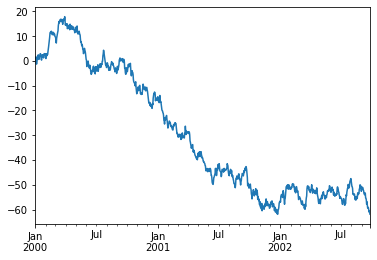

```python
ts.plot()
```

```python
df = pd.DataFrame(np.random.randn(1000, 4), index=ts.index,
                   columns=['A', 'B', 'C', 'D'])
```

```python
import matplotlib.pyplot as plt
```

```python
df = df.cumsum()
```

```python
plt.figure()
```

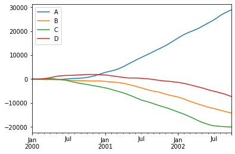

```python
df.plot()
```

```python
df.to_csv('foo.csv')
```

```python
pd.read_csv('foo.csv')
```

|  | Unnamed: 0 | A | B | C | D |
| --- | --- | --- | --- | --- | --- |
| 0 | 2000-01-01 | 0.380354 | -0.715600 | 0.477168 | -0.615242 |
| 1 | 2000-01-02 | 0.032450 | -0.499093 | 1.974019 | -1.195866 |
| 2 | 2000-01-03 | -1.851622 | -0.711985 | 3.225540 | -2.417393 |
| 3 | 2000-01-04 | -3.696595 | -0.400146 | 2.866099 | -3.908053 |
| 4 | 2000-01-05 | -5.003217 | 1.256739 | 0.959486 | -5.810246 |
| ... | ... | ... | ... | ... | ... |
| 995 | 2002-09-22 | 28714.956464 | -14075.504773 | -19965.084587 | -7135.555466 |
| 996 | 2002-09-23 | 28754.517214 | -14097.688732 | -19968.603250 | -7164.606749 |
| 997 | 2002-09-24 | 28795.287024 | -14120.607755 | -19972.122136 | -7191.300242 |
| 998 | 2002-09-25 | 28835.603030 | -14143.746478 | -19975.695661 | -7217.591645 |
| 999 | 2002-09-26 | 28874.365164 | -14166.375748 | -19980.493471 | -7243.154593 |

1000 rows × 5 columns

```python
df
```

|  | A | B | C | D |
| --- | --- | --- | --- | --- |
| 2000-01-01 | 0.380354 | -0.715600 | 0.477168 | -0.615242 |
| 2000-01-02 | 0.032450 | -0.499093 | 1.974019 | -1.195866 |
| 2000-01-03 | -1.851622 | -0.711985 | 3.225540 | -2.417393 |
| 2000-01-04 | -3.696595 | -0.400146 | 2.866099 | -3.908053 |
| 2000-01-05 | -5.003217 | 1.256739 | 0.959486 | -5.810246 |
| ... | ... | ... | ... | ... |
| 2002-09-22 | 28714.956464 | -14075.504773 | -19965.084587 | -7135.555466 |
| 2002-09-23 | 28754.517214 | -14097.688732 | -19968.603250 | -7164.606749 |
| 2002-09-24 | 28795.287024 | -14120.607755 | -19972.122136 | -7191.300242 |
| 2002-09-25 | 28835.603030 | -14143.746478 | -19975.695661 | -7217.591645 |
| 2002-09-26 | 28874.365164 | -14166.375748 | -19980.493471 | -7243.154593 |

1000 rows × 4 columns

```python
df.to_excel('foo.xlsx', sheet_name='Sheet1')
```

[output not shown]

2021-07-01

```python
import numpy as np
```

```python
a = np.arange(15).reshape(3, 5)
```

```python
# numpy 中的数组类为 ndarray 别名为 array。 下方是ndarray的一些属性
a
```

```
array([[ 0,  1,  2,  3,  4],
       [ 5,  6,  7,  8,  9],
       [10, 11, 12, 13, 14]])
```

```python
a.shape
```

```
(3, 5)
```

```python
a.ndim
```

```
2
```

```python
a.dtype
```

```
dtype('int32')
```

```python
a.dtype.name
```

```
'int32'
```

```python
a.size
```

```
15
```

```python
# --------------------------------------------------------------------------------------------------
# 创建数组的几种方法
```

```python
a = np.array([1, 2, 3])   # 一维数组     该方法类似于 torch.tensor()
a
```

```
array([1, 2, 3])
```

```python
b = np.array([[1, 1, 2, 3], [4, 5, 6, 7], [6, 7, 8, 9]])  # 多维数组
b
```

```
array([[1, 1, 2, 3],
       [4, 5, 6, 7],
       [6, 7, 8, 9]])
```

```python
c = np.array([[1, 2], [3, 4]], dtype=complex)  # 创建数组的同时设置类型
c
```

```
array([[1.+0.j, 2.+0.j],
       [3.+0.j, 4.+0.j]])
```

```python
a = np.zeros( (3,4) )
b = np.ones( (2,3,4), dtype=np.int16 )
c = np.empty( (2,3) )             # 未初始化
```

```python
np.arange( 10, 30, 5 )            # [start, end) 左闭右开，5 为步长不是个数
```

```
array([10, 15, 20, 25])
```

```python
np.linspace( 0, 2, 9 )            # [start, end] 左闭右闭， 9 为个数不是步长
```

```
array([0.  , 0.25, 0.5 , 0.75, 1.  , 1.25, 1.5 , 1.75, 2.  ])
```

```python
# array， zeros， zeros_like， ones， ones_like， empty， empty_like， arange， linspace，
# numpy.random.rand， numpy.random.randn  用法都和 torch 相同
```

```python
# 强制打印所有数据，需进行以下设置
# np.set_printoptions(threshold=sys.maxsize)       # sys module should be imported
```

```python
# -------------------------------------------------------------------------------------------------
# 基本操作
```

```python
a = np.array([20,30,40,50])
a < 35
```

```
array([ True,  True, False, False])
```

```python
A = np.array( [[1,1], [0,1]] )
B = np.array( [[2,0], [3,4]] )
A * B                  # 对应元素相乘
```

```
array([[2, 0],
       [0, 4]])
```

```python
A @ B                  # 矩阵乘法    A.dot(B) 与其作用一样
```

```
array([[5, 4],
       [3, 4]])
```

```python
# 某些操作（例如+=和 *=）会更直接更改被操作的矩阵数组而不会创建新矩阵数组。
```

```python
#  bin.max()    b.sum(axis=0)    b.min(axis=1)    可指定轴运算
```

```python
# 通函数
# B = np.arange(3)
# np.exp(B)
# np.sqrt(B) 。。。
```

```python
# all， any， apply_along_axis， argmax， argmin， argsort， average， bincount， ceil， clip， conj， corrcoef，
# cov， cross， cumprod， cumsum， diff， dot， floor， inner， INV ， lexsort， max， maximum， mean， median， min，
# minimum， nonzero， outer， prod， re， round， sort， std， sum， trace， transpose， var， vdot， vectorize， where
```

```python
'''支持 切片索引

当提供的索引少于轴的数量时，缺失的索引被认为是完整的切片

三个点（ ... ）表示产生完整索引元组所需的冒号。例如，如果 x 是rank为5的数组（即，它具有5个轴），则：
    [1,2,...] 相当于 x[1,2,:,:,:]，
    x[...,3] 等效于 x[:,:,:,:,3]
    x[4,...,5,:] 等效于 x[4,:,:,5,:]。'''
```

```python
a = np.arange(10)**3
a
```

```
array([  0,   1,   8,  27,  64, 125, 216, 343, 512, 729], dtype=int32)
```

```python
def foo(x,y):
    return 10 * x + y

b = np.fromfunction(foo, (5, 4), dtype=int)
b
```

```
array([[ 0,  1,  2,  3],
       [10, 11, 12, 13],
       [20, 21, 22, 23],
       [30, 31, 32, 33],
       [40, 41, 42, 43]])
```

```python
for row in b:        # 对多维数组进行 迭代（Iterating） 是相对于第一个轴完成的
    print(row)
```

```
[0 1 2 3]
[10 11 12 13]
[20 21 22 23]
[30 31 32 33]
[40 41 42 43]
```

```python
for element in b.flat:    # 如果想要对数组中的每个元素执行操作，可以使用flat属性，该属性是数组的所有元素的迭代器
    print(element)
```

```
0
1
2
3
10
11
12
13
20
21
22
23
30
31
32
33
40
41
42
43
```

```python
# -------------------------------------------------------------------------------------------------------
# 形状操作
```

```python
a = np.floor(10*np.random.random((3,4)))       # np.random.random 会从 0 到 1 随机取浮点数
a
```

```
array([[8., 1., 9., 4.],
       [4., 1., 3., 8.],
       [1., 7., 4., 0.]])
```

```python
a.ravel()            # 铺平       不改变原数组
```

```
array([8., 1., 9., 4., 4., 1., 3., 8., 1., 7., 4., 0.])
```

```python
a.reshape(6,2)       # 重塑       不改变原数组
```

```
array([[8., 1.],
       [9., 4.],
       [4., 1.],
       [3., 8.],
       [1., 7.],
       [4., 0.]])
```

```python
a.T                 # 转置       不改变原数组
```

```
array([[8., 4., 1.],
       [1., 1., 7.],
       [9., 3., 4.],
       [4., 8., 0.]])
```

```python
# -------------------------------------------------------------------------------------------------------
# 将不同数组堆叠在一起
```

```python
a = np.floor(10*np.random.random((2,2)))
a
```

```
array([[0., 7.],
       [6., 9.]])
```

```python
b = np.floor(10*np.random.random((2,2)))
b
```

```
array([[5., 2.],
       [0., 5.]])
```

```python
np.vstack((a,b))
```

```
array([[0., 7.],
       [6., 9.],
       [5., 2.],
       [0., 5.]])
```

```python
np.hstack((a,b))
```

```
array([[0., 7., 5., 2.],
       [6., 9., 0., 5.]])
```

```python
# -------------------------------------------------------------------------------------------------------
# 拆分数组
```

```python
a = np.floor(10*np.random.random((2,12)))
a
```

```
array([[8., 7., 7., 3., 9., 9., 0., 0., 1., 8., 9., 7.],
       [9., 0., 4., 3., 0., 3., 6., 0., 6., 7., 4., 4.]])
```

```python
np.hsplit(a,3)   # 沿水平轴切分为 3 份
```

```
[array([[8., 7., 7., 3.],
        [9., 0., 4., 3.]]),
 array([[9., 9., 0., 0.],
        [0., 3., 6., 0.]]),
 array([[1., 8., 9., 7.],
        [6., 7., 4., 4.]])]
```

```python
np.hsplit(a,(3,4))   # 沿水平轴切分为 [0, 3)  [3, 4)  [4, end]
```

```
[array([[8., 7., 7.],
        [9., 0., 4.]]),
 array([[3.],
        [3.]]),
 array([[9., 9., 0., 0., 1., 8., 9., 7.],
        [0., 3., 6., 0., 6., 7., 4., 4.]])]
```

```python
# -------------------------------------------------------------------------------------------------------
# 拷贝和视图
```

```python
a = np.arange(12)
b = a            # 不复制，a 和 b 指向同一个东西，是引用
a is b
```

```
True
```

```python
id(a)
```

```
2274070787152
```

```python
id(b)
```

```
2274070787152
```

```python
import numpy as np
```

```python
a = np.arange(12)
c = a.view()       # 不同的数组对象可以共享相同的数据。该view方法创建一个查看相同数据的新数组对象。
c is a
```

```
False
```

```python
c.base is a
```

```
True
```

```python
# 切片数组会返回一个视图
```

```python
d = a.copy()        # copy方法生成数组及其数据的完整副本. 深拷贝
d is a
```

```
False
```

```python
d.base is a
```

```
False
```

```python
# -------------------------------------------------------------------------------------------------------
# 花式索引
```

```python
a = np.arange(12) ** 2
i = np.array([1, 1, 3, 8, 5])
a
```

```
array([  0,   1,   4,   9,  16,  25,  36,  49,  64,  81, 100, 121],
      dtype=int32)
```

```python
a[i]
```

```
array([ 1,  1,  9, 64, 25], dtype=int32)
```

```python
# 当索引数组a是多维的时，单个索引数组指的是第一个维度a
palette = np.array( [ [0,0,0],                # black
                      [255,0,0],              # red
                      [0,255,0],              # green
                      [0,0,255],              # blue
                      [255,255,255] ] )       # white
image = np.array( [ [ 0, 1, 2, 0 ],           # each value corresponds to a color in the palette
                    [ 0, 3, 4, 0 ]  ] )
palette[image]                            # the (2,4,3) color image
```

```
array([[[  0,   0,   0],
        [255,   0,   0],
        [  0, 255,   0],
        [  0,   0,   0]],

       [[  0,   0,   0],
        [  0,   0, 255],
        [255, 255, 255],
        [  0,   0,   0]]])
```

2021-06-06

常见问题及解决方法

# c语言数组赋值问题

数组正常初始化是没问题的

```
1
```

```
char ch[50] = "Reindeer";
```

但是分步赋值，或重新赋值就会报错

```
1
2
3
4
5
6
7
8
9
```

```
// 分步赋值
char ch[50];
ch = "Reindeer";

// 重新赋值
char ch[50] = "Reindeer";
ch = "Ethereal";

// 报错  Array type 'char [50]' is not assignable
```

**原因**： ch 就是字符数组的首地址，是一个常量，不能作为左值。

**解决**：可以使用 strcpy 函数赋值

```
1
2
```

```
char ch[50];
strcpy(ch, "Ethereal");
```

2021-05-31

JavaWeb系列学习笔记

# javaScript学习笔记

javaScript 也是万物皆对象。

## 数据类型

ES6开始，所有的局部变量声明都用let，ES5及之前所有的变量声明都用var。

ES6开始支持 “use strict” 即严格检查模式，预防javaScript的随意性导致的一些问题，使用时必须写在javaScript的第一行

#### 数值

弱类型，无需指定具体类型，只看做变量即可。

```
1
2
3
```

```
let a = 1;
let b = 1.2;
let c = 1e5;
```

#### 字符串

字符串是常量，不可变。

单引号或双引号都可以，还可以用反引号写多行文字。特殊字符用 \ 转义。\n \r 等与其他语言一样。

**模板字符串**（和EL表达式一样） ES6才有

```
1
2
```

[output not shown]

**方法**：java中String的方法基本都有，且名字和作用都一样。在js中字符串可以使用下标，且length是属性不是方法。

#### 数组

js中数组的长度可变：通过给arr.length赋值，可改变数组长度。若变大，新扩展单元为undefined；若变小，则截取前半段

同一个数组中可以包含任意的数据类型，如下：

```
1
```

```
let arr = [1, "hello", 2.5, 'c', true];
```

**方法**

```
1
2
3
4
5
6
7
8
9
10
11
12
13
14
15
16
17
18
19
20
21
22
```

```
arr.length;                        // 数组长度
------------------------------------------------------------------------
arr.indexOf(2.5);                  // 通过元素索引下标
------------------------------------------------------------------------
// 若数组中同时包含 数字1 和字符串"1" ，则他俩不一样
------------------------------------------------------------------------
newArr = arr.slice(2)              // 从下标2开始复制到末尾，返回新数组
newArr = arr.slice(2, 4)           // 从下标2开始复制下标4，返回新数组
------------------------------------------------------------------------
// 作为栈使用
arr.push("Reindeer");              // 向数组尾部压入元素
arr.pop();                         // 从数组尾部弹出元素
arr.unshift("Reindeer");           // 向数组头部压入元素
arr.shift();                       // 从数组头部弹出元素
// 两者结合也可以用作队列
------------------------------------------------------------------------
// 其他常用方法
arr.sort();                        // 排序  [1, 2.5, "c", "hello", true]
arr.reverse();                     // 反转  [true, "hello", "c", 2.5, 1]
arr.concat([3, 4, 5]);             // 拼接，返回新数组，不改变原数组。
arr.join('--')                     // 连接为字符串，"1--2.5--c--hello--true"
let arr = [[1, 2, 3], [4, 5, 6],[7, 8, 9]];  // 多维数组
```

#### 对象

js 的对象长得和 python 的字典一样。键都为字符串，值任意

1、定义对象

```
1
2
3
4
5
```

```
let person = {
    name: "Reindeer",
    gender: "male",
    age: 18
}
```

2、给对象属性赋值

```
1
```

```
person.age = 19;
```

3、删除属性

```
1
```

```
delete person.age;
```

4、添加属性

```
1
```

```
person.phone = "123456789"
```

## 流程控制

if、else 、while、for 等都与其他语言一样。下面列出特有语法：

- forEach。向 forEach 中传入一个函数，这个函数将作用于 arr 中的所有元素。

```
1
2
3
```

```
arr.forEach(function(value) {
    console.log(value)
})
```

- for … of …

```
1
2
3
4
```

```
let arr = [2, 3, 6, 1, 8, 4];
for (let value of arr) {              // 这里value是数组中的值
    console.log(value);
}
```

- for … in …

```
1
2
3
4
```

```
let arr = [2, 3, 6, 1, 8, 4];
for (let index in arr) {              // 这里index是数组的下标
    console.log(arr[index]);
}
```

## 数据结构

#### Map

```
1
2
3
4
5
6
7
8
9
10
11
12
13
14
```

```
let map = new Map([["alice", 18], ["mary", 20], ["reindeer", 19]]);
Map(3) {"alice" => 18, "mary" => 20, "reindeer" => 19}

map.get("alice")        // 通过key获得value
18

map.set("alice", 17)    // 用 set 修改值
Map(3) {"alice" => 17, "mary" => 20, "reindeer" => 19}

map.set("lucy", 18)    // 用 set 添加值
Map(4) {"alice" => 17, "mary" => 20, "reindeer" => 19, "lucy" => 18}

map.delete("alice")    // 删除
true
```

#### Set

无序不重复

```
1
2
3
4
5
6
7
8
9
10
11
```

```
let set = new Set([3, 5, 6, 2, 5, 8, 2]);    // 去重
Set(5) {3, 5, 6, 2, 8}

set.has(3)             // 判断是否含有指定值
true

set.add(7)             // 添加
Set(6) {3, 5, 6, 2, 8, 7}

set.delete(2)          // 删除
true
```

#### Iterator

遍历数组用 for … in … 和 for … of … 都可以。

遍历 Map 和 Set 只能用 for … of … ，如下：

```
1
2
3
4
5
6
7
```

```
for (let x of map) {
    console.log(x)
}

for (let x of set) {
    console.log(x)
}
```

## 函数

#### 函数定义

由于是弱类型，故和python一样，无需指定返回类型。

```
1
2
3
4
5
6
7
8
9
```

```
// 定义方式一
function add(a, b) {          // 关键字 function 的功能和 python 的 def 一样，指明这是一个函数。
    return a + b;
}
// 定义方式二
let add = function(a, b) {
    return a + b;
}
// 以上两种定义方式效果一样，调用方式也一样
```

#### 参数处理

调用函数时，若传入的参数比需要的参数少，或者参数的类型不正确，js会返回NaN；若传入的参数比需要的多，函数只接受前n个他需要的参数，其余参数不理会，但是也不报错。故需要我们手动处理参数。

关键字 **arguments** 是一个数组，其中存储了调用函数时传入的全部的参数。

关键字 **rest **是一个数组，其中存储了调用函数时传入的多余的参数。

```
1
2
3
4
5
6
7
8
9
10
11
12
13
```

```
// 若想使用 rest 关键字，定义函数时参数必须这样写，即在所有参数的末尾加上 ", ...rest" 。固定写法
function add(a, b, ...rest) {
    if (arguments.length < 2) {                              // 传入参数过少
        throw "Incorrect number of parameters!"
    }
    if (typeof a !== "number" || typeof b !== "number") {    // 参数类型不正确
        throw "not a number!";
    }
    console.log(rest);
    return a + b;
}
// 若调用函数时为 add(2, 3, 4, 5, 6, 7);
// 则 arguments === [2, 3, 4, 5, 6, 7]     rest === [4, 5, 6, 7]
```

#### 变量作用域

[let和var的区别以及const](https://www.jianshu.com/p/9f7f053f7204)， 一句话就是 var 为函数作用域， let 为块作用域

和java一样，变量选择遵守就近原则，即从自己所在的层级开始查找，如果没有，向上一级查找，直至找到window，若还是没有就报错undefined

所有的全局变量都是 **window** 对象的属性，只要是定义在函数外的变量就是全局变量，函数本身也属于全局变量。

问题：由于所有的全局变量都会注册为window的属性，则当多个js文件的全局变量都注册到window时，若发生重名，就会产生冲突。

解决方法：每个用户将自己的全局变量都注册到自己的命名空间中，仅将自己的命名空间注册到window。

```
1
2
3
4
5
6
7
8
```

```
// 唯一全局变量
var Reindeer = {};

// 其余变量都注册到命名空间Reindeer中
Reindeer.name = "xunlu";
Reindeer.add = function(a, b) {
    return a + b;
}
```

#### 方法

正常写法

```
1
2
3
4
5
6
7
8
9
```

```
let MrLu = {
    name: 'xunlu',
    birthDay: 2000,
    // 定义在对象中的函数即为方法
    age: function () {
        let now = new Date().getFullYear();
        return now - this.birthDay;  // 此处必须用this，否则报错。而java可以不用this
    }
}
```

还可以分开写（就离谱）

```
1
2
3
4
5
6
7
8
9
10
```

```
function getAge() {
    let now = new Date().getFullYear();
    return now - this.birthDay;
}

let MrLu = {
    name: 'xunlu',
    birthDay: 2000,
    age: getAge
}                  // 调用时 ： MrLu.age()
```

**apply** 关键字 可以将一个外部方法指向一个对象，并使用对象中的资源。

```
1
2
3
4
5
6
7
8
9
10
11
12
13
```

```
function getAge() {
    let now = new Date().getFullYear();
    return now - this.birthDay;
}

let MrLu = {
    name: 'xunlu',
    birthDay: 2000,
    age: getAge
}

// js中所有的函数都有 apply 这个方法
getAge.apply(MrLu, []);  // 将函数 getAge 的 this 指向 MrLu 对象，并传入参数为空（本函数需要的参数）
```

#### 内置对象

Data

```
1
2
3
4
```

```
let data = new Date();  // Sat Jun 05 2021 14:57:16 GMT+0800 (中国标准时间)
data.getFullYear();   // 年
data.getMonth();      // 月
// 等等，用时按字面意思取就行了，分不清就在浏览器上测试。
```

JSON

```
1
2
```

```
JSON.stringify(Object);   // 对象转json字符串
JSON.parse(String);       // json字符串解析为对象
```

## 面向对象编程

原型 （ ES5及之前使用）【除非迫不得已，不要用这个】

```
1
2
3
4
5
6
7
8
9
10
11
12
```

```
let person = {
    name: "Reindeer",
    gender: "male",
    age: 18
};

let jack = {
    name: "jack"
};

// 将 jack 的原型指向 person ，可以将 person 视为模板。此时 jack 也有了 gender 和 age 属性。
jack.__proto__ = person;
```

**class 继承** （ES6 引入） 本质还是__proto__，但是更人性。

```
1
2
3
4
5
6
7
8
9
10
11
12
13
14
15
16
17
18
19
20
21
22
23
24
25
26
27
28
29
30
31
32
33
```

```
// 定义一个教师类
class Teacher {
    constructor(name) {
        this.name = name;
    }

    teach() {
        alert(this.name + " teacher is teaching the lecture");
    }
}

// 实例化
let yo = new Teacher("yo");
---------------------------------------------------------------------------
// 继承
class MathTeacher extends Teacher {
    constructor(name, discipline) {
        super(name);
        this.discipline = discipline;
    }

    // 独有方法
    great() {
        alert("I am a " + this.discipline + " teacher");
    }

    // 重写方法
    teach() {
        alert(this.name + " teacher is teaching the " + this.discipline);
    }
}

let ya = new MathTeacher("ya", "math");
```

## 操作 BOM 对象 【重点】

BOM (Browser Object Model) 是指**浏览器对象模型**，是用于描述一种对象与对象之间层次关系的模型。

**window** 对象代表浏览器本身

```
1
2
3
4
5
6
7
8
9
10
```

```
window.alert(1)
undefined
window.innerHeight      // 页面大小
855
window.innerWidth
132
window.outerHeight      // 整个浏览器窗口大小
1040
window.outerWidth
1920
```

navigator 封装了浏览器的信息。（不建议使用这个，因为这些信息可以被人为修改）

```
1
2
3
4
5
6
```

```
navigator.appVersion
"5.0 (Windows NT 10.0; Win64; x64) AppleWebKit/537.36 (KHTML, like Gecko) Chrome/91.0.4472.77 Safari/537.36 Edg/91.0.864.41"
navigator.userAgent
"Mozilla/5.0 (Windows NT 10.0; Win64; x64) AppleWebKit/537.36 (KHTML, like Gecko) Chrome/91.0.4472.77 Safari/537.36 Edg/91.0.864.41"
navigator.platform
"Win32"
```

screen 封装了屏幕的信息。

```
1
2
3
4
```

```
screen.width
1920
screen.height
1080
```

location 表示当前页面的 url 信息

```
1
2
3
4
5
6
7
8
```

```
location.host
"www.baidu.com"
location.href
"https://www.baidu.com/"
location.protocol
"https:"
location.reload()          // 重新加载
location.assign("https://fanyi.youdao.com/");   // 重定位到参数所在地址
```

**document** 代表当前页面 【最重要的功能即为操作 DOM 树】

```
1
2
3
4
5
6
```

```
document.title                 // 页面标题
"百度一下，你就知道"
document.title = "Reindeer"    // 修改页面标题
"Reindeer"
document.cookie                // 获取网页的cookie
"BAIDUID=0C870627CC96D001F4A2D895A9500E68:FG=1;
```

history 代表浏览器的历史记录

```
1
2
```

```
history.forward()   // 前进      作用与浏览器左上角的 左右箭头 一样
history.back()      // 后退
```

## 操作 DOM 对象 【重点】

DOM（Document Object Model）指 **文档对象模型**。

浏览器页面就是一个 DOM 树形结构！

#### 获取 DOM 节点

**js 文件必须在需获取的标签下面，否则获取不到**，因此一般将 js 的引用放在页面的最底部

```
1
2
3
4
```

```
document.getElementById()                 // id 名        唯一
document.getElementsByTagName()           // 标签名       返回数组
document.getElementsByClassName()         // 类名         返回数组
// 获取到 DOM 节点后，又可以根据 .children  .firstChild  .lastChild  获取相应子节点
```

#### 修改 DOM 节点

```
1
2
3
4
```

```
let id1 = document.getElementById("id1");
id1.innerText = "123";                     // 修改文本内容。 2、3行代码作用一样，会将原标签下所有内容覆盖
id1.innerHTML = "<strong>123</strong>";    // 修改文本内容，可以解析HTML标签
id1.style.color = "red";                   // 修改 CSS 样式
```

#### 删除 DOM 节点

先获取父节点，然后根据父节点删除子节点。不能自己删除自己。

```
1
2
3
4
5
6
7
8
9
10
```

```
<div id="id1">
    <p id="p1">p1</p>
    <p class="p2">p2</p>
</div>

<script>
    let self = document.getElementById("p1");   // 获取自己
    let father = self.parentElement;            // 获取父节点
    father.removeChild(self);                   // 通过父节点删除自己
</script>
```

获取到父节点之后，也可以通过`father.removeChild(father.children[i]);`删除相应子节点。**注意**：在删除过程中，`father.children`数组在动态改变，需要注意下标的正确性。

#### 插入 DOM 节点

移动已存在的节点

```
1
2
3
4
5
6
7
8
9
10
11
12
13
```

```
<p id="python">python</p>

<div id="list">
    <p id="c">c</p>
    <p id="c++">c++</p>
    <p id="java">java</p>
</div>

<script>
    let python = document.getElementById("python");
    let list = document.getElementById("list");
    list.appendChild(python);    // 将 id 为 python 的标签追加到 list 标签中，且删除原标签
</script>
```

创建新的节点

```
1
2
3
4
5
6
```

```
let newP = document.createElement("p");    // 新建
newP.setAttribute("id", "newP");           // 设置 id 属性，同样方法也可以设置其他属性
newP.innerHTML = "hello, reindeer";        // innerHTML 自然也可以添加文本
list.appendChild(newP);                    // 追加
---------------------------------------------------
list.insertBefore(newP, python);           // 将 newP 节点插入到 python 节点之前。 （新节点， 参考节点）
```

## 操作表单

表单的目的就是提交信息

#### 获取和修改表单信息

```
1
2
3
4
5
6
7
8
9
10
11
12
13
14
15
16
17
18
19
20
21
22
```

```
<form action="#" method="POST">
    <p>
        <span>username: </span>  <input type="text" name="username" id="username">
    </p>

    <p>
        <span>gender: </span>        <!-- radio 表示单选框 -->
        <input type="radio" name="gender" value="man" id="boy"> 男
        <input type="radio" name="gender" value="woman" id="girl"> 女
    </p>
</form>

<script>
    let username = document.getElementById("username");
    let boy = document.getElementById("boy");
    let girl = document.getElementById("girl");
    username.value;                   // 获取文本框中的内容
    username.value = "123";           // 设置文本框中的内容

    boy.checked;                      // 获取当前单选框是否被选中，返回 boolean 值
    girl.checked = true;              // 将当前单选框设置为选中
</script>
```

#### 提交表单

```
1
2
3
4
5
6
7
8
9
10
11
12
13
14
15
16
17
18
19
20
21
22
23
24
```

```
<!-- onsubmit 给表单绑定一个检测函数 -->
<form action="https://www.baidu.com/" method="POST" onsubmit="return check()">
    <p>
        <span>username: </span>  <input type="text" name="username" id="username">
    </p>
    <!-- name 用于接收提交的值 -->
    <p>
        <span>password: </span>  <input type="password" id="input-password">
    </p>

    <input type="hidden" name="password" id="md5-password">

    <input type="submit">
</form>

<script>
    function check() {
        let username = document.getElementById("username");
        let password = document.getElementById("input-password");
        let md5password = document.getElementById("md5-password");

        md5password.value = md5(password.value);
    }
</script>
```

2021-05-22

JavaWeb系列学习笔记

# Redis学习笔记

### 概述

Redis是什么？

Redis（Remote Dictionary Server )，即远程字典服务！

Redis能干吗？==数据库、缓存、中间件==

1. 内存存储、持久化（rdb、aof）
2. 效率高，可用于缓存
3. 发布订阅系统
4. 地图信息分析
5. 计时器、计数器 。。。

### Linux安装配置redis

下载并解压redis后，将解压好的包移动到`/usr/local/redis`中，然后`cd /usr/local/redis`，依次在该目录下执行`make`，`make test`（也可以不执行）和`make install`。之后将该目录下的`redis.conf`备份，再`vim redis.conf`，将`daemonize`的值从no改为yes。`cd /usr/local/bin`，执行`redis-server ../redis/redis.conf`。配置完成。

### 基础知识

redis所有命令不区分大小写

##### 数据库基本命令

redis默认有16个数据库（0~15），默认使用第0个数据库。数据库之间数据相互隔离

```
1
2
3
4
5
6
7
8
9
```

```
127.0.0.1:6379> SELECT 3      # 切换数据库
OK
127.0.0.1:6379[3]> DBSIZE     # 查看当前数据库大小
(integer) 0
127.0.0.1:6379> FLUSHDB       # 清空当前数据库
OK
127.0.0.1:6379> FLUSHALL      # 清空所有数据库
OK
127.0.0.1:6379> SHUTDOWN      # 关闭redis服务
```

##### Redis-key基本命令

```
1
2
3
4
5
6
7
8
9
10
11
12
13
14
15
16
17
18
19
```

```
127.0.0.1:6379> set age 18            # 添加键值对
OK
127.0.0.1:6379> get name              # 通过key获取value
"xunlu"
127.0.0.1:6379> KEYS *                # KEYS + 正则表达式。返回所有符合正则表达式的键
1) "age"
2) "name"
127.0.0.1:6379> EXISTS name           # 判断是否存在指定的key
(integer) 1                           # 返回1则存在，0则不存在
127.0.0.1:6379> EXPIRE name 10        # 设置键name的有效期为10秒
(integer) 1
127.0.0.1:6379> ttl name              # 查看键name的有效时间还剩下多少
(integer) 4
127.0.0.1:6379> MOVE name 1           # 将键值对移动到指定的数据库中
(integer) 1
127.0.0.1:6379> DEL name              # 删除键值对
(integer) 1
127.0.0.1:6379> TYPE age              # 获取当前键对应值的类型
string
```

##### redis 6 引入了多线程

redis 5 及之前的版本一直使用的是单线程，6引入也是为了解决IO问题，核心的执行业务依然采用单线程。

redis 将所有的数据都放在内存中。单线程避免切换上下文，所以快。

### 数据类型

##### 五种基本数据类型

- String —> 应用：计数器（如访问量，点赞数等）

```
1
2
3
4
5
6
7
8
9
10
11
12
13
14
15
16
17
18
19
20
21
22
23
24
25
26
27
28
29
30
31
32
33
34
35
36
37
38
39
40
41
42
43
44
45
46
47
48
49
50
51
52
53
54
55
56
57
58
59
60
61
62
63
64
65
```

```
127.0.0.1:6379> set name xunlu
OK
127.0.0.1:6379> APPEND name feilu              # 追加字符串，类似StringBuilder的append
(integer) 10                                   # 若追加的键不存在，则新建键值对
127.0.0.1:6379> get name
"xunlufeilu"
-----------------------------------------------
127.0.0.1:6379> STRLEN name					 # 返回值的长度
(integer) 10
-----------------------------------------------
127.0.0.1:6379> set views 0
OK
127.0.0.1:6379> INCR views                     # 每执行一次，值就会加1.（只能作用于integer类型）
(integer) 1
127.0.0.1:6379> INCR views
(integer) 2
127.0.0.1:6379> DECR views                     # 每执行一次，值就会减1.（只能作用于integer类型）
(integer) 1
127.0.0.1:6379> INCRBY views 10                # 指定增加的步长
(integer) 11
127.0.0.1:6379> DECRBY views 10                # 指定减少的步长
(integer) 1
-----------------------------------------------
127.0.0.1:6379> set name xunlu
OK
127.0.0.1:6379> GETRANGE name 0 2              # 截取部分值（start和end都包括在内）
"xun"
127.0.0.1:6379> GETRANGE name 0 -1             # == get name
"xunlu"
127.0.0.1:6379> SETRANGE name 0 gao            # 替换部分字符，起始替换位置 + 替换的值
(integer) 5
127.0.0.1:6379> get name
"gaolu"
-----------------------------------------------
# setex(set with expire)   【原子性操作】
# setnx(set if not exist)  【原子性操作】
127.0.0.1:6379> setex name 30 xunlu            # 新建键值对，并设置有效期为30秒
OK   # 等同于 set name xunlu ex 30             # 新建可以，对已有的键值对执行会报错，原因不明（EXPIRE）
127.0.0.1:6379> setnx gender male              # nx表示键不存在时才能正确执行，即只能新建
OK   # 等同于 set gender male nx               # 常用于分布式锁
127.0.0.1:6379> get gender
"male"
127.0.0.1:6379> set gender female nx           # 此时键gender已经存在，执行失败
(nil)
-----------------------------------------------
127.0.0.1:6379> MSET k1 v1 k2 v1 k3 v1         # 批量创建键值对
OK
127.0.0.1:6379> KEYS *
1) "k1"                                        # msetnx 【原子性操作】
2) "k3"
3) "k2"
127.0.0.1:6379> MGET k1 k2 k3                  # 批量获取
1) "v1"
2) "v1"
3) "v1"
------------------------------------------------
127.0.0.1:6379> set user {id:1,name:xunlu,age:3} # 可以将值设为json字符串，然后通过json解析
OK
127.0.0.1:6379> mset user:name xunlu user:age 18 # redis支持键中存在`:`冒号，亦可用于解析
OK
------------------------------------------------
127.0.0.1:6379> getset db redis                  # 先get再set。没有返回nil，再设新值
(nil)
127.0.0.1:6379> getset db redis                  # 有则返回旧值，再设新值
"redis"
```

- List（双向链表）
  - 绝大部分的list命令都以l开头，list的名字也可作为key，故有些redis-key的命令也可用
  - 应用：消息队列、栈

```
1
2
3
4
5
6
7
8
9
10
11
12
13
14
15
16
17
18
19
20
21
22
23
24
25
26
27
28
29
30
31
32
33
34
35
36
37
38
39
40
41
42
43
44
```

```
# 添加、范围读取
LPUSH key element [element ...]                   # key为列表的名字，添加到列表的头部
RPUSH key element [element ...]                   # 添加到列表的尾部
127.0.0.1:6379> LPUSH list mid                    # 列表名为list，head、mid、tail为元素
(integer) 1
127.0.0.1:6379> LPUSH list head
(integer) 2
127.0.0.1:6379> RPUSH list tail
(integer) 3
127.0.0.1:6379> LRANGE list 0 -1
1) "head"
2) "mid"
3) "tail"
127.0.0.1:6379> LRANGE list 0 1                   # 从头向尾读，没有RRANGE这个命令
1) "head"
2) "mid"
--------------------------------------------------
# 删除、改变list
LPOP key [count]                                  # 从头部弹出元素
RPOP key [count]                                  # 从尾部弹出元素
LREM key count element                            # 根据值移除元素，count表示从多个相同的值中移除的个数
LTRIM key start stop                              # 将列表截断，只保留[start ~ stop]的值
--------------------------------------------------
# 按下标索引
127.0.0.1:6379> LINDEX list 0                     # 获取list的第i个值
"head"
127.0.0.1:6379> LINDEX list 1
"mid"
--------------------------------------------------
# 长度
127.0.0.1:6379> LLEN list                         # 获取list的长度
(integer) 3
--------------------------------------------------
# 组合命令
RPOPLPUSH source destination                     # 从容器source的尾部弹出并添加到容器destination的头部
"tail"                                           # source和destination自然可以是同一个列表
-------------------------------------------------
# 修改列表中的值
LSET key index element                           # 修改列表指定下标处的值
127.0.0.1:6379> LSET list 0 prehead
OK
-------------------------------------------------
# 插值
LINSERT key BEFORE|AFTER pivot element          # pivot为列表中已有的元素，往列表中元素的前或后插入元素
```

- Set（无序不重复）（命令都以s打头）

```
1
2
3
4
5
6
7
8
9
10
11
12
13
14
15
16
17
18
19
20
21
22
23
24
25
26
27
28
29
```

```
# 添加、查看
SADD key member [member ...]                    # 添加元素（可以批量）
127.0.0.1:6379> SADD set first second third
(integer) 3
127.0.0.1:6379> SMEMBERS set                    # 查看所有元素
1) "second"
2) "third"
3) "first"
127.0.0.1:6379> SISMEMBER set first             # 判断是否包含指定元素
(integer) 1
127.0.0.1:6379> SISMEMBER set fifth
(integer) 0
127.0.0.1:6379> SCARD set				       # 集合的长度
(integer) 3
-------------------------------------------------
# 移除
SREM key member [member ...]                    # 删除指定元素（可以批量）
SPOP key [count]                                # 随机删除元素（可以指定个数）
SMOVE source destination member                 # 将指定元素从集合source移动到集合destination
-------------------------------------------------
SRANDMEMBER key [count]                         # 随机返回元素（可以指定个数）
-------------------------------------------------
# 集合计算
# 差集
SDIFF set1 set2                                 # 集合set1中有但set2中没有的元素
# 交集
SINTER set1 set2                                # 交
# 并集
SUNION set1 set2                                # 并
```

- Hash（命令都以h打头）
  - 相当于map，则变为key-(key-value)，故（更适合对象的存储）

```
1
2
3
4
5
6
7
8
9
10
11
12
13
14
15
16
17
18
19
20
21
22
23
24
25
26
27
28
29
30
31
32
33
34
35
36
37
38
39
40
```

```
# 添加
HSET key field value [field value ...]           # 存值，key为hash容器的名字
HMSET key field value [field value ...]          # 批量存值
127.0.0.1:6379> HSET hash name xunlu
(integer) 1
127.0.0.1:6379> HSET hash age 18
(integer) 1
-------------------------------------------------
# 查看
HGET key field                                   # 指定字段的取值
HMGET key field [field ...]                      # 批量取值
127.0.0.1:6379> HGET hash name
"xunlu"
127.0.0.1:6379> HGETALL hash                     # 查看全部内容
1) "name"
2) "xunlu"
3) "age"
4) "18"
-------------------------------------------------
# 删除
HDEL key field [field ...]                       # 删除指定元素（可批量）
-------------------------------------------------
# 长度
127.0.0.1:6379> HLEN hash
(integer) 2
-------------------------------------------------
# 是否存在
HEXISTS key field                                # 判断指定字段是否存在
-------------------------------------------------
127.0.0.1:6379> HKEYS hash                       # 取全部字段名
1) "name"
2) "age"
127.0.0.1:6379> HVALS hash                       # 取全部字段的值
1) "xunlu"
2) "18"
-------------------------------------------------
# 自增、自减
HINCRBY key field increment                      # field = field + increment （increment为负数即为减）
-------------------------------------------------
HSETNX key field value                           # 和setnx作用类似
```

- Zset（有序集合）【底层为跳表】

```
1
2
3
4
5
6
7
8
9
10
11
12
13
14
15
16
17
18
19
20
21
22
```

```
# 添加、查看
ZADD key score member [score member ...]          # score用于排序
127.0.0.1:6379> ZADD salary 2500 mary 3000 alice 1000 lisa
(integer) 3
ZRANGE salary 0 -1                                # 返回所有数据
--------------------------------------------------
# 排序
ZRANGEBYSCORE key min max [WITHSCORES] [LIMIT offset count]      # 小到大
ZREVRANGEBYSCORE key max min [WITHSCORES] [LIMIT offset count]   # 大到小
127.0.0.1:6379> ZRANGEBYSCORE salary -inf +inf    # 返回score在-inf +inf之间元素的排序，小到大
1) "lisa"
2) "mary"
3) "alice"
--------------------------------------------------
# 移除
ZREM key member [member ...]
--------------------------------------------------
# 长度
127.0.0.1:6379> ZCARD salary                      # 总个数
(integer) 3
127.0.0.1:6379> zcount salary 2000 3000           # 指定区间个数（score的区间）
(integer) 2
```

##### 三种特殊数据类型

- Geospatial 地理位置 【底层由Zset实现、因此可以使用zset的命令，如ZREM等】

```
1
2
3
4
5
6
7
8
9
10
11
12
13
14
15
16
17
18
19
20
21
22
23
24
25
26
```

[output not shown]

- Hypeloglog（基数统计、即去重后计数）【占用内存很小，最大只需要12KB】（有0.81%错误率）

```
1
2
3
4
5
6
7
```

```
PFADD key element [element ...]                  # 添加
PFCOUNT key [key ...]                            # 基数统计
127.0.0.1:6379> pfadd key a a a a l k j h j k l d
(integer) 1
127.0.0.1:6379> PFCOUNT key
(integer) 6
PFMERGE destkey sourcekey [sourcekey ...]        # 合并
```

- Bitmaps（位图）
  - 位存储、只有两种状态的都可以用它存储

```
1
2
3
```

```
SETBIT key offset value                          # 添加，其中value的值只能是 0 或 1
GETBIT key offset                                # 查看
BITCOUNT key [start end]                         # 统计value为 1 的个数
```

### 事务

Redis事务的本质是一组命令的集合。事务执行一次执行多个命令。一个事务中的所有命令都会被序列化，在事务执行过程中，会按顺序执行。其他客户端提交的命令请求不会插入到事务队列中执行。 （一次性、顺序性、排他性）

==Redis的单条命令保证原子性，但是Redis的事务不保证原子性！==

认为Redis不保证原子性是因为**Redis 事务不支持事务回滚机制**，即如果事务队列中的命令存在逻辑错误（运行时异常），则Redis 事务执行过程中对于出错命令返回错误，然后继续执行之后的命令。但是Redis 使用了事务队列来预先将执行命令存储起来，并且会对其进行格式检查，提前就知道命令是否可执行了。所以如果只要有一个命令是错误的（编译期异常），就会将错误返回，那么这个事务是不能执行的。

==Redis事务没有隔离级别的概念==

因为是单线程操作。

##### Redis事务执行

- 开启事务（multi）
- 命令入队
- 执行事务 （exec）

```
1
2
3
4
5
6
7
8
9
10
11
12
13
14
15
16
17
18
19
20
21
22
23
24
25
26
27
28
29
30
31
```

```
# 正常执行事务
127.0.0.1:6379> MULTI                  # 开启事务
OK
# 命令入队
127.0.0.1:6379(TX)> set k1 v1
QUEUED
127.0.0.1:6379(TX)> set k2 v2
QUEUED
127.0.0.1:6379(TX)> get k2
QUEUED
127.0.0.1:6379(TX)> set k3 v3
QUEUED
127.0.0.1:6379(TX)> exec               # 执行事务
1) OK
2) OK
3) "v2"
4) OK
----------------------------------------
# 放弃事务
127.0.0.1:6379> MULTI
OK
127.0.0.1:6379(TX)> set k1 v1
QUEUED
127.0.0.1:6379(TX)> set k2 v2
QUEUED
127.0.0.1:6379(TX)> set k4 v4
QUEUED
127.0.0.1:6379(TX)> DISCARD             # 放弃事务（所有命令都不执行）
OK
127.0.0.1:6379> get k4
(nil)                                   # 说明 set k4 v4 命令并未执行
```

##### 监控（watch）

WATCH命令可以监控一个或多个键，一旦其中有一个键被修改（或删除），之后的事务就不会执行。监控一直持续到EXEC命令（事务中的命令是在EXEC之后才执行的，所以在MULTI命令后可以修改WATCH监控的键值）（只要执行了EXEC命令或者DISCARD命令，不论其执行是否成功，都会自动取消所有的监控）

**乐观锁**：乐观锁在操作数据时非常乐观，认为别人不会同时修改数据。

因此乐观锁不会上锁，只是在执行更新的时候判断一下在此期间别人是否修改了数据：如果别人修改了数据则放弃操作，否则执行操作。

**悲观锁**：悲观锁在操作数据时比较悲观，认为别人会同时修改数据。

因此操作数据时直接把数据锁住，直到操作完成后才会释放锁；上锁期间其他人不能修改数据

```
1
2
3
4
5
6
7
8
9
10
11
12
13
14
15
16
```

```
# 正常执行成功（即在事务执行期间确实没有修改数据）
127.0.0.1:6379> set in 100
OK
127.0.0.1:6379> set out 0
OK
127.0.0.1:6379> WATCH in                 # 监控 in 对象
OK
127.0.0.1:6379> MULTI
OK
127.0.0.1:6379(TX)> INCRBY in -20
QUEUED
127.0.0.1:6379(TX)> INCRBY out 20
QUEUED
127.0.0.1:6379(TX)> EXEC                 # 事务正常结束，在事务执行期间外部没有修改数据
1) (integer) 80
2) (integer) 20
```

watch 可以用作 Redis 的乐观锁

```
1
2
3
4
5
6
7
8
9
10
11
12
13
14
15
16
17
18
19
20
21
```

```
# 在事务执行期间外部了修改数据，则执行失败
127.0.0.1:6379> set in 100
OK
127.0.0.1:6379> set out 0
OK
127.0.0.1:6379> WATCH in                 # 监控 in 对象
OK
127.0.0.1:6379> MULTI
OK
127.0.0.1:6379(TX)> INCRBY in -20
QUEUED
127.0.0.1:6379(TX)> INCRBY out 20
QUEUED
-------------------------------------------
# 此处为另外打开一个bash执行的操作
127.0.0.1:6379> set in 200               # 模拟另一个线程修改数据
OK
-------------------------------------------
# 返回原bash执行事务
127.0.0.1:6379(TX)> EXEC                 # WATCH 监控到 in 对象发生改变，执行失败
(nil)
```

### Jedis

Jedis是Redis官方推荐的java连接开发工具，是java操作redis的中间件。

1. 导入依赖jedis和fastjson
2. 测试连接

```
1
2
3
4
5
6
7
8
```

```
public class TestPing {
    public static void main(String[] args) {
        Jedis jedis = new Jedis("192.168.202.128", 6379);
        // jedis 所有的命令都是之前学习的redis的命令【全部一样】
        System.out.println(jedis.ping());
        jedis.close();       // 关闭连接
    }
}
```

3. 关于事务

```
1
2
3
4
5
6
7
8
9
10
11
12
13
14
15
16
17
18
19
20
21
22
23
```

```
public class TestPing {
    public static void main(String[] args) {
        Jedis jedis = new Jedis("192.168.233.128", 6379);

        jedis.flushDB();
        Transaction transaction = jedis.multi();    // 开启事务

        try {
            transaction.set("name", "xunlu");
            transaction.set("age", "18");
            transaction.incr("name");        // 此处为运行时错误，正常执行其余指令
            transaction.exec();
        } catch (Exception e) {
            // 此句是为了在当try块中出现如10/0等java的错误，而非redis的错误时放弃执行事务的。
            transaction.discard();
            e.printStackTrace();
        }

        System.out.println(jedis.get("name"));

        jedis.close();       // 关闭连接
    }
}
```

### SpringBoot整合

在SpringBoot 2.x之后，底层由jedis换为了lettuce。

jedis：采用的直连，多个线程操作是不安全的，想要避免不安全需要使用jedis pool连接池。更像 bio模式

lettuce：采用netty，实例可以在多个线程中共享，不存在不安全发情况，可以减少线程数据。更像 nio模式

1、 导入依赖

```
1
2
3
4
```

```
<dependency>
    <groupId>org.springframework.boot</groupId>
    <artifactId>spring-boot-starter-data-redis</artifactId>
</dependency>
```

2、 配置连接

```
1
2
```

```
spring.redis.host=192.168.233.128     # 配置ip
spring.redis.port=6379                # 端口号默认为6379，可以不配
```

3、 使用介绍

```
1
2
3
4
5
6
7
8
9
10
11
12
13
14
15
16
17
18
19
20
21
22
23
```

```
@Autowired
private RedisTemplate<?, ?> redisTemplate;   // 注入模板类

@Test
void contextLoads() {

    // 获取连接 (一般很少用)
    RedisConnection connection = redisTemplate.getConnectionFactory().getConnection();
    connection.flushDb();

    /*
     * opsForValue()    操作字符串
     * opsForList()     操作List
     * opsForGeo()      操作Geo
     * 等等，类似上方对于8中数据类型都可以操作，选定操作对象后，具体方法和redis完全一样
     */
    redisTemplate.opsForValue().set("name", "xunlu");

    // 一些基本操作和常用方法都可以直接使用
    redisTemplate.multi();       // 开启事务
    redisTemplate.keys();        // 查询键
    redisTemplate.rename();      // 重命名
}
```

##### 序列化

由于redis是要存储的，因此redis对象必须实现序列化（实际开发中，所有pojo包下的对象都需要实现序列化）。springboot默认的序列化为`JdkSerializationRedisSerializer`，该序列化会使中文转义。我们一般使用JSON来序列化。

```
1
2
3
4
5
6
7
8
9
10
11
12
13
14
15
16
17
18
19
20
21
22
23
24
25
26
27
28
```

```
// 固定通用的配置，用到时直接复制即可
@Configuration
public class RedisConfig {

    // 编写自己的Template
    @Bean
    public RedisTemplate<String, Object> redisTemplate(RedisConnectionFactory redisConnectionFactory) {
        RedisTemplate<String, Object> template = new RedisTemplate<>();
        template.setConnectionFactory(redisConnectionFactory);

        // json的序列化配置
        Jackson2JsonRedisSerializer<Object> jsonRedisSerializer = new Jackson2JsonRedisSerializer<>(Object.class);
        ObjectMapper objectMapper = new ObjectMapper();
        objectMapper.setVisibility(PropertyAccessor.ALL, JsonAutoDetect.Visibility.ANY);
        objectMapper.activateDefaultTyping(LaissezFaireSubTypeValidator.instance);
        jsonRedisSerializer.setObjectMapper(objectMapper);
        // String的序列化配置
        StringRedisSerializer stringRedisSerializer = new StringRedisSerializer();

        template.setKeySerializer(stringRedisSerializer);     // key采用string序列化方法
        template.setValueSerializer(jsonRedisSerializer);     // Value采用json序列化方法
        template.setHashKeySerializer(stringRedisSerializer); // HashKey采用string序列化方法
        template.setHashValueSerializer(jsonRedisSerializer); // HashValue采用json序列化方法
        template.afterPropertiesSet();

        return template;
    }
}
```

### Redis.conf 解析

redis.conf 解析

### Redis持久化

Redis是内存数据库，若不持久化到磁盘中，则redis进程一旦退出，数据就会丢失，因此需要持久化。

##### RDB(Redis DataBase)

在指定的时间间隔内将内存中的数据快照写入磁盘，恢复时将快照文件直接读入内存。

Redis会单独创建（fork）一个子进程来进行持久化，会先将数据保存进一个临时文件中，待持久化过程结束了，再将这个临时文件替换上次持久化的文件。整个过程中，主进程不参与任何IO操作，因此性能高。

rdb保存的文件是dump.rdb。同样可以在redis.conf中修改

```
1
2
3
4
```

```
在redis.conf中对自动保存的间隔进行设置
# save 3600 1        After 3600 seconds (an hour) if at least 1 key changed
# save 300 100       After 300 seconds (5 minutes) if at least 100 keys changed
# save 60 10000      After 60 seconds if at least 10000 keys changed
```

**触发机制**

1、 满足上方save的规则，会持久化

2、执行flushall，会持久化

3、退出reids，会持久化

**恢复rdb文件**

```
1
2
3
4
```

```
# 若rdb文件在下方目录下，则启动时会自动回复其中的数据
127.0.0.1:6379> CONFIG GET dir
1) "dir"
2) "/usr/local/bin"
```

##### AOF(Append Only File)

将所有写命令都记录到文件中、恢复时把该文件再执行一遍，只允许追加该记录文件，不允许修改。该记录文件的名字为`appendonly.aof`。该功能默认不开启。